# DS6306_Case_2

David Wei

8/1/2020

### Introduction

**Due to recent changes in the employee workforce, an analytics company “DDSAnalytics” has requested a study to analyze the potential factors that lead to up to employee Attrition and Monthly Income as well as providing forecasts based on those estimates. The focus of this case study will be on discovering trends, patterns and clues that help us formulate an overall predictive strategy. Additionally, once our predictive models have been created, we will discuss the accuracy of the models with varying sets of data. This case study will be primarily split into 4 parts: Data Tidying, EDA, Feature Selection and lastly our Classification & Prediction models. Enjoy!**

### Setup & General Libraries

```r
library(tidyr)
library(dplyr)
library(ggplot2)
library(tidyverse)
library(GGally)

setwd("C:/Users/David/Google Drive/Masters/Summer 2020/DS 6306 - Doing Data Science/Case Study 2/")
df <- read.csv("CaseStudy2-data.csv", header=TRUE)
```

### Data Profiling & Tidying

**As part of the data tidying process, we first want to verify if the dataset contains any missing or uncategorized data for any of the attributes. As shown below, we can confirm that all data is being populated. Once missing and uncategorized data was validated, we then created a combined dataset with our categorical variables dummycoded as “IDs”s and “Desc” for factor types for ease of use throughout the study.**

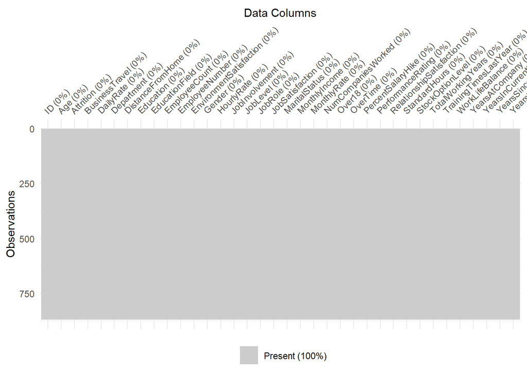

```r
# verifying empty data
library(naniar)
vis_miss(df) + xlab("Data Columns")
```

```r
# exploring unique categorical values
cat_types <- c(3,4,6,9,13,17,19,23,24)
for(i in cat_types){
  print(colnames(df[i]))
  print(df %>% count(df[,i]))
}
```

```
## [1] "Attrition"
## # A tibble: 2 x 2
##   `df[, i]`     n
##   <chr>     <int>
## 1 No          730
## 2 Yes         140
## [1] "BusinessTravel"
## # A tibble: 3 x 2
##   `df[, i]`             n
##   <chr>             <int>
## 1 Non-Travel           94
## 2 Travel_Frequently   158
## 3 Travel_Rarely       618
## [1] "Department"
## # A tibble: 3 x 2
##   `df[, i]`                  n
##   <chr>                  <int>
## 1 Human Resources           35
## 2 Research & Development   562
## 3 Sales                    273
## [1] "EducationField"
## # A tibble: 6 x 2
##   `df[, i]`            n
##   <chr>            <int>
## 1 Human Resources     15
## 2 Life Sciences      358
## 3 Marketing          100
## 4 Medical            270
## 5 Other               52
## 6 Technical Degree    75
## [1] "Gender"
## # A tibble: 2 x 2
##   `df[, i]`     n
##   <chr>     <int>
## 1 Female      354
## 2 Male        516
## [1] "JobRole"
## # A tibble: 9 x 2
##   `df[, i]`                     n
##   <chr>                     <int>
```

[output cut: 12 more lines]

```
##   <chr>     <int>
## 1 Divorced    191
## 2 Married     410
## 3 Single      269
## [1] "Over18"
## # A tibble: 1 x 2
##   `df[, i]`     n
##   <chr>     <int>
## 1 Y           870
## [1] "OverTime"
## # A tibble: 2 x 2
##   `df[, i]`     n
##   <chr>     <int>
## 1 No          618
## 2 Yes         252
```

```r
# taking a look into spread of our response variable (Attrition)
table(df$Attrition)
```

```
##
##  No Yes
## 730 140
```

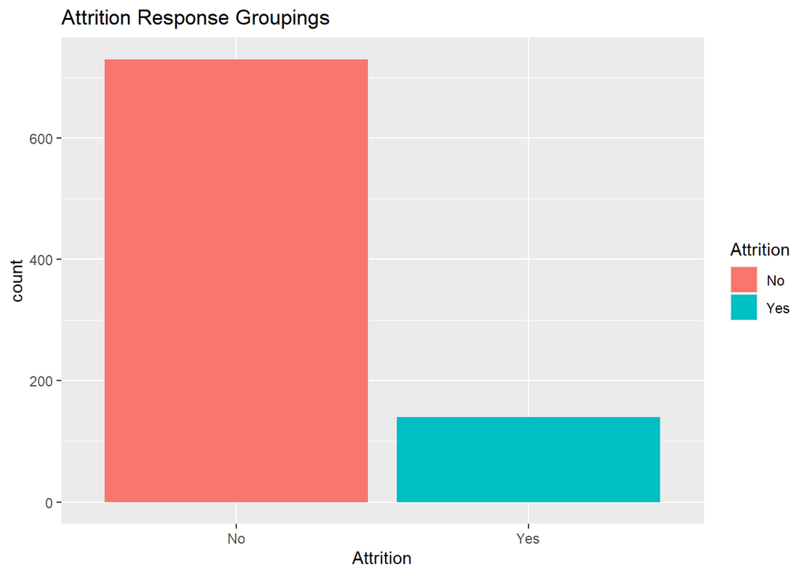

```r
df %>% ggplot(aes(x=Attrition, fill=Attrition)) + geom_bar() + labs(title="Attrition Response Groupings")
```

```r
# new df containing ID and all converted categorical variables into factor types
df_cat <- df
for(i in cat_types){
  df_cat[, i] <- factor(df_cat[,i])
  x <- paste(colnames(df_cat[i]),"desc", sep="_")
  colnames(df_cat)[i] <- paste(x)
}
# all categorical values including ID
cat_columns <- c(1,3,4,6,9,13,17,19,23,24)
df_cat_short <- data.frame(df_cat[, cat_columns])

# new df containing ID and all converted categorical variables into numerical types
df_num <- df
# df_num$Attrition <- factor(df_num$Attrition)
for(i in cat_types){
  df_num[, i] <- as.numeric(factor(df_num[,i]))
  x <- paste(colnames(df_num[i]),"ID", sep="_")
  colnames(df_num)[i] <- paste(x)
}
df_num_short <- data.frame(df_num[, cat_columns])

# storying all numerical data into temp df excluding categorical types
df_temp <- df[, -cat_types]

# joining the categorical factors (desc) with it's numerical types (IDs)
df_short <- merge(x=df_num_short, y=df_cat_short, by="ID", all.x=TRUE)
df_short <- df_short[c(1,2,11,3,12,4,13,5,14,6,15,7,16,8,17,9,18,10,19)]

# joining all numerical with categorical data together as final df
df_final <- merge(x=df_short, y=df_temp, by="ID", all=TRUE)
head(df_final, 1)
```

```
##   ID Attrition_ID Attrition_desc BusinessTravel_ID BusinessTravel_desc
## 1  1            1             No                 3       Travel_Rarely
##   Department_ID Department_desc EducationField_ID EducationField_desc Gender_ID
## 1             3           Sales                 2       Life Sciences         2
##   Gender_desc JobRole_ID    JobRole_desc MaritalStatus_ID MaritalStatus_desc
## 1        Male          8 Sales Executive                1           Divorced
##   Over18_ID Over18_desc OverTime_ID OverTime_desc Age DailyRate
## 1         1           Y           1            No  32       117
##   DistanceFromHome Education EmployeeCount EmployeeNumber
## 1               13         4             1            859
##   EnvironmentSatisfaction HourlyRate JobInvolvement JobLevel JobSatisfaction
## 1                       2         73              3        2               4
##   MonthlyIncome MonthlyRate NumCompaniesWorked PercentSalaryHike
## 1          4403        9250                  2                11
##   PerformanceRating RelationshipSatisfaction StandardHours StockOptionLevel
## 1                 3                        3            80                1
##   TotalWorkingYears TrainingTimesLastYear WorkLifeBalance YearsAtCompany
## 1                 8                     3               2              5
##   YearsInCurrentRole YearsSinceLastPromotion YearsWithCurrManager
## 1                  2                       0                    3
```

### Creating Training/Test Sets & Downsampling

**By observing our response variable, we noticed that our variable of interest (Attrition) had a large majority of the dataset comprised exclusively of employees who did not leave the company (minority being 16%). This stark contrast in attribute values could cause unwanted bias to our model. To account for it, we applied downsampling techniques to level such imbalances. Since the smaller set of attrition values totaled around 140 observations, we created a training and test split with downsampling applied for more accurate clarity and clearer distinction of separation in our model.**

```r
# Train/Test split with cleaned data
set.seed(27)
splitPerc = .70
df_index = sample(1:dim(df_final)[1],round(splitPerc * dim(df_final)[1]))
df_train = df_final[df_index,]
df_test = df_final[-df_index,]

table(df_final$Attrition_ID) #original
```

```
##
##   1   2
## 730 140
```

```r
table(df_train$Attrition_ID) #train
```

```
##
##   1   2
## 507 102
```

```r
table(df_test$Attrition_ID) #test
```

```
##
##   1   2
## 223  38
```

```r
# Train/Test data with Downsampling Applied
library(caret)
df_final_downsampled <- downSample(x = df_final,y = df_final$Attrition_desc)
df_train_downsampled <- downSample(x = df_train,y = df_train$Attrition_desc)
df_test_downsampled <- downSample(x = df_test,y = df_test$Attrition_desc)

table(df_final_downsampled$Attrition_ID) #original downsampled
```

```
##
##   1   2
## 140 140
```

```r
table(df_train_downsampled$Attrition_ID) # train downsampled
```

```
##
##   1   2
## 102 102
```

```r
table(df_test_downsampled$Attrition_ID) # test downsampled
```

```
##
##  1  2
## 38 38
```

### EDA - Part 1 - Analysis of Numerical Types

**From a quick summary statistics on all available columns, our first goal is to see if there’s any variables we can easily cross-off as insignificant based on all data available. From this exercise, we can see that there a few variables that either do not change much or have minimal amounts of variance such a EmployeeCount, PerformanceRating and StandardHours. Due to such little variation in these variables, we can safely remove them as potential factors to attrition to avoid overfitting our model. From this initial summary review, we can also immediately see that the “Over18” column is comprised exclusively of “Y”s, which in result will have no signifance to any of our models due to it’s static nature.**

**EDA based Reduced numerical attributes (Round 1): OVer18, EmployeeCount, PerformanceRating and StandardHours**

```r
library(corrplot)
library(ggExtra)
library(cowplot)
library(GGally)

# viewing quick sumamry statistics of all our numerical data
num_types <- c(20:45)
summary(df_final[,num_types])
```

```
##       Age          DailyRate      DistanceFromHome   Education
##  Min.   :18.00   Min.   : 103.0   Min.   : 1.000   Min.   :1.000
##  1st Qu.:30.00   1st Qu.: 472.5   1st Qu.: 2.000   1st Qu.:2.000
##  Median :35.00   Median : 817.5   Median : 7.000   Median :3.000
##  Mean   :36.83   Mean   : 815.2   Mean   : 9.339   Mean   :2.901
##  3rd Qu.:43.00   3rd Qu.:1165.8   3rd Qu.:14.000   3rd Qu.:4.000
##  Max.   :60.00   Max.   :1499.0   Max.   :29.000   Max.   :5.000
##  EmployeeCount EmployeeNumber   EnvironmentSatisfaction   HourlyRate
##  Min.   :1     Min.   :   1.0   Min.   :1.000           Min.   : 30.00
##  1st Qu.:1     1st Qu.: 477.2   1st Qu.:2.000           1st Qu.: 48.00
##  Median :1     Median :1039.0   Median :3.000           Median : 66.00
##  Mean   :1     Mean   :1029.8   Mean   :2.701           Mean   : 65.61
##  3rd Qu.:1     3rd Qu.:1561.5   3rd Qu.:4.000           3rd Qu.: 83.00
##  Max.   :1     Max.   :2064.0   Max.   :4.000           Max.   :100.00
##  JobInvolvement     JobLevel     JobSatisfaction MonthlyIncome
##  Min.   :1.000   Min.   :1.000   Min.   :1.000   Min.   : 1081
##  1st Qu.:2.000   1st Qu.:1.000   1st Qu.:2.000   1st Qu.: 2840
##  Median :3.000   Median :2.000   Median :3.000   Median : 4946
##  Mean   :2.723   Mean   :2.039   Mean   :2.709   Mean   : 6390
##  3rd Qu.:3.000   3rd Qu.:3.000   3rd Qu.:4.000   3rd Qu.: 8182
##  Max.   :4.000   Max.   :5.000   Max.   :4.000   Max.   :19999
##   MonthlyRate    NumCompaniesWorked PercentSalaryHike PerformanceRating
##  Min.   : 2094   Min.   :0.000      Min.   :11.0      Min.   :3.000
##  1st Qu.: 8092   1st Qu.:1.000      1st Qu.:12.0      1st Qu.:3.000
##  Median :14074   Median :2.000      Median :14.0      Median :3.000
##  Mean   :14326   Mean   :2.728      Mean   :15.2      Mean   :3.152
##  3rd Qu.:20456   3rd Qu.:4.000      3rd Qu.:18.0      3rd Qu.:3.000
##  Max.   :26997   Max.   :9.000      Max.   :25.0      Max.   :4.000
##  RelationshipSatisfaction StandardHours StockOptionLevel TotalWorkingYears
##  Min.   :1.000            Min.   :80    Min.   :0.0000   Min.   : 0.00
##  1st Qu.:2.000            1st Qu.:80    1st Qu.:0.0000   1st Qu.: 6.00
##  Median :3.000            Median :80    Median :1.0000   Median :10.00
##  Mean   :2.707            Mean   :80    Mean   :0.7839   Mean   :11.05
##  3rd Qu.:4.000            3rd Qu.:80    3rd Qu.:1.0000   3rd Qu.:15.00
##  Max.   :4.000            Max.   :80    Max.   :3.0000   Max.   :40.00
##  TrainingTimesLastYear WorkLifeBalance YearsAtCompany   YearsInCurrentRole
##  Min.   :0.000         Min.   :1.000   Min.   : 0.000   Min.   : 0.000
##  1st Qu.:2.000         1st Qu.:2.000   1st Qu.: 3.000   1st Qu.: 2.000
##  Median :3.000         Median :3.000   Median : 5.000   Median : 3.000
##  Mean   :2.832         Mean   :2.782   Mean   : 6.962   Mean   : 4.205
##  3rd Qu.:3.000         3rd Qu.:3.000   3rd Qu.:10.000   3rd Qu.: 7.000
##  Max.   :6.000         Max.   :4.000   Max.   :40.000   Max.   :18.000
##  YearsSinceLastPromotion YearsWithCurrManager
##  Min.   : 0.000          Min.   : 0.00
##  1st Qu.: 0.000          1st Qu.: 2.00
##  Median : 1.000          Median : 3.00
##  Mean   : 2.169          Mean   : 4.14
##  3rd Qu.: 3.000          3rd Qu.: 7.00
##  Max.   :15.000          Max.   :17.00
```

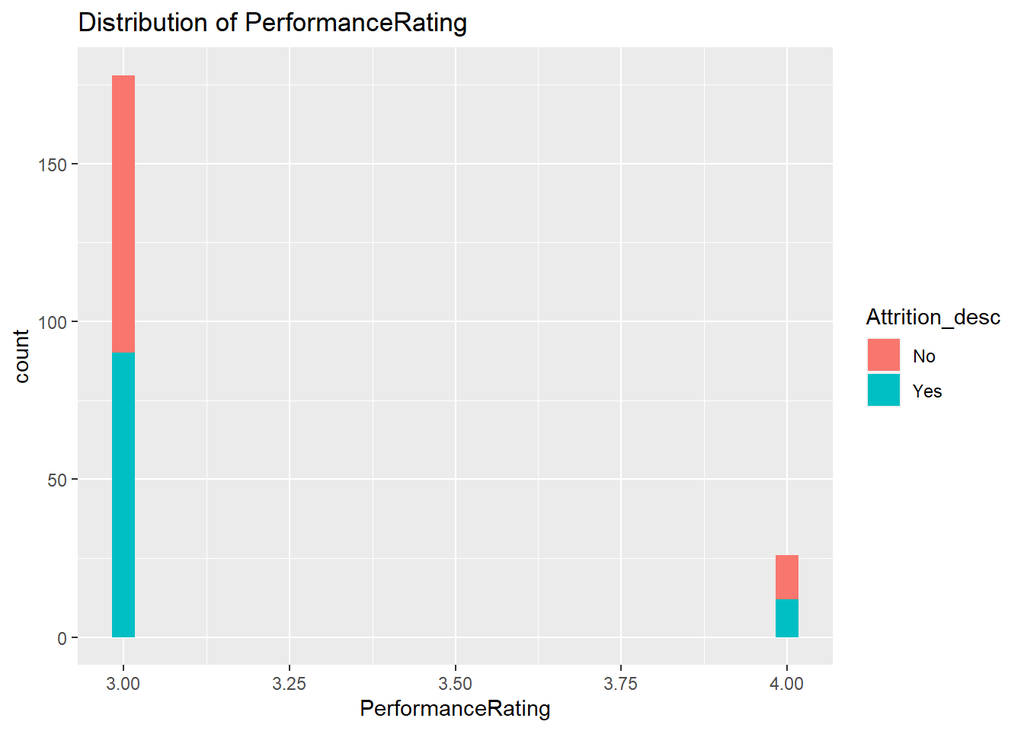

```r
# EmployeeCount and StandardHours are static values. We can also see that almost 85% of all employees have a performance rating of 3. Additionally, we can also see that there is almost no relationship between Attrition and the employee rating so we can also remove it as a potential variable.
df_train_downsampled %>% ggplot(aes(x=PerformanceRating, fill=Attrition_desc)) + geom_histogram() + labs(title="Distribution of PerformanceRating")
```

```r
abs(cor(df_train_downsampled$PerformanceRating, df_train_downsampled$Attrition_ID))
```

```
## [1] 0.02939905
```

### EDA - Part 1 - Numerical Types - Correlation Matrix

**We then plotted out a correlation matrix to better evaluate the remaining numerical variable types. To form the baseline of our analysis, we will look closer into any correlations higher than corr=.75. We first begin by analyzing the relationship between Job Level and Monthly Income which we has extremely strong correlation (r=.95). We can see that as job level increases, the monthly income increases as well indicating that as an employee ranks up in terms of job level, so does his/her monthly income. Given this assumption, we can safely remove JobLevel from the picture. What’s interesting here is that though MonthlyIncome and HourlyRates are both indicators of an employee’s potential earnings, there’s almost no correlation between the two, indicating that though standard hours remain constant, there are potentially unprovided external factors such as # of weeks work, working hours, etc. that may influence these variables.**

**Another highly correlated relationships were between YearsInCurrentRole and YearsAtCompany (r=.81). When investigating this strong relationship, we can see that the number of years in the current role is significantly tied to the total number of years at the company. In other words, it’s uncommon for an individual to stay in the same role for more than 10 years, but also in that same regards, equally unlikely that the same individual will stay at the company for more than 10 years also. As a result, there is simply less Attrition data the larger the length is at a company as most people tend to stay at a company between 0-10 years. Even more importantly, when we look into the years stayed at the company and the distribution of Attrition per year, it’s surprisngly balanced between those who left and those who stayed! Therefore we can conclude that in terms of Attrition, neither the number of years at the company nor the years with current manager contributes to attrition.**

**EDA based Reduced numerical attributes (Round 2): JobLevel, YearsWithCurrManager, YearsInCurrentRole, NumCompaniesWorked,**

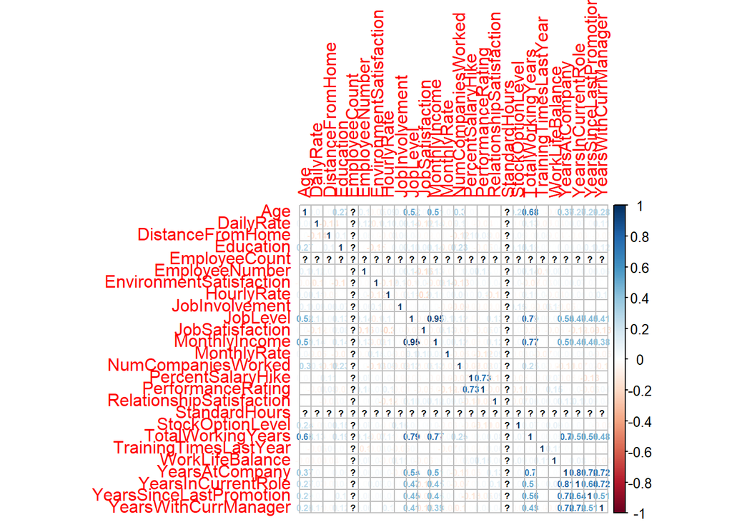

```r
# creating correlation matrix  of numerical datatypes
corr_matrix_num <- df_train_downsampled[,c(20:45)]
M <- cor(corr_matrix_num, use="pairwise.complete.obs")
corrplot(M, method = "number", order = "alphabet",number.cex=0.5)
```

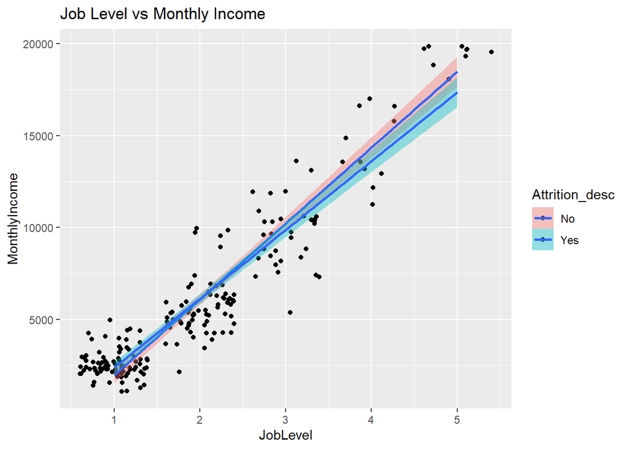

```r
# JobLevel vs MonthlyIncome
ggplot(df_train_downsampled, aes(x=JobLevel, y=MonthlyIncome, fill=Attrition_desc)) + geom_jitter() +geom_smooth(method="lm") + labs(title="Job Level vs Monthly Income")
```

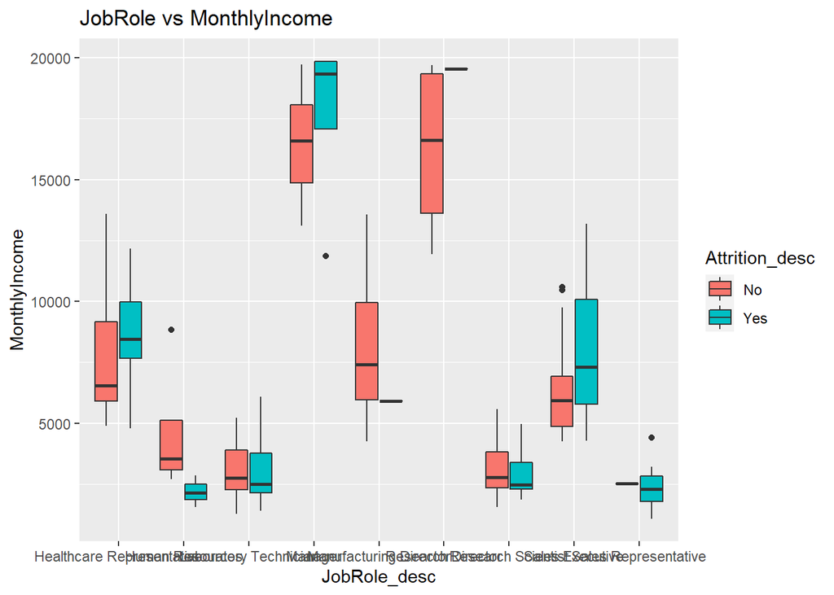

```r
# JobRole vs MonthlyIncome
ggplot(df_train_downsampled, aes(x=JobRole_desc, y=MonthlyIncome, fill=Attrition_desc)) + geom_boxplot() + labs(title="JobRole vs MonthlyIncome")
```

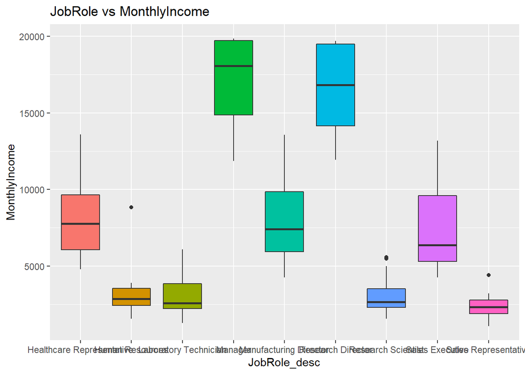

```r
ggplot(df_train_downsampled, aes(x=JobRole_desc, y=MonthlyIncome, fill=JobRole_desc)) + geom_boxplot() +
  theme(legend.position = "none") + labs(title="JobRole vs MonthlyIncome")
```

```r
# Analysis into JobLevel and Job Role Trends
df_train_downsampled %>% count(df_train_downsampled$JobRole_desc)
```

```
## # A tibble: 9 x 2
##   `df_train_downsampled$JobRole_desc`     n
##   <fct>                               <int>
## 1 Healthcare Representative              16
## 2 Human Resources                         7
## 3 Laboratory Technician                  34
## 4 Manager                                 9
## 5 Manufacturing Director                 14
## 6 Research Director                      10
## 7 Research Scientist                     45
## 8 Sales Executive                        52
## 9 Sales Representative                   17
```

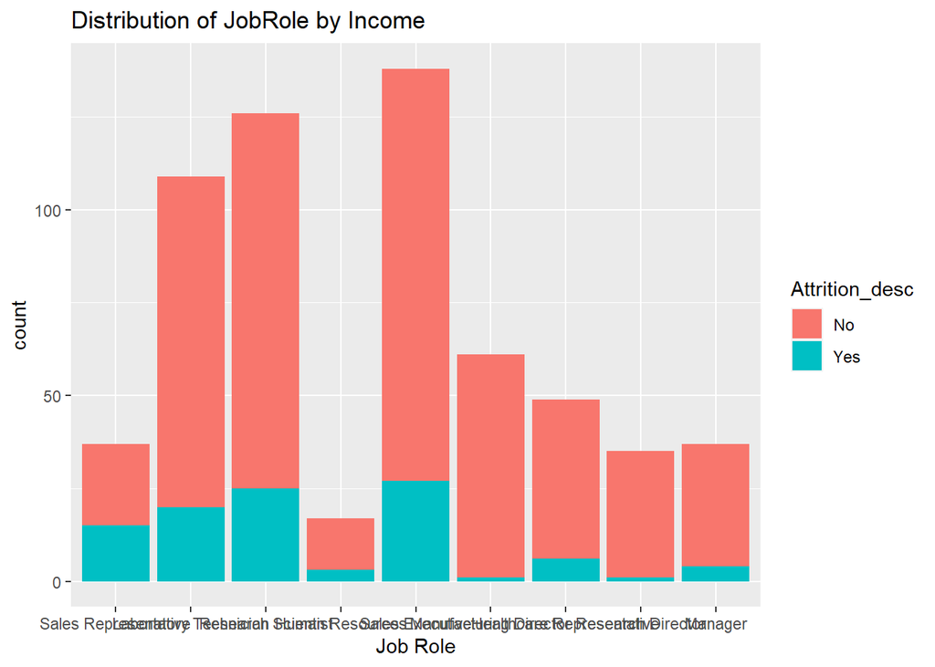

```r
job_role_order <- c('Sales Representative', 'Laboratory Technician', 'Research Scientist', 'Human Resources', 'Sales Executive', 'Manufacturing Director', 'Healthcare Representative', 'Research Director', 'Manager')
ggplot(df_train, aes(x=factor(JobRole_desc, level=job_role_order))) + geom_histogram(stat="count", aes(fill=Attrition_desc)) + labs(title="Distribution of JobRole by Income", x="Job Role")
```

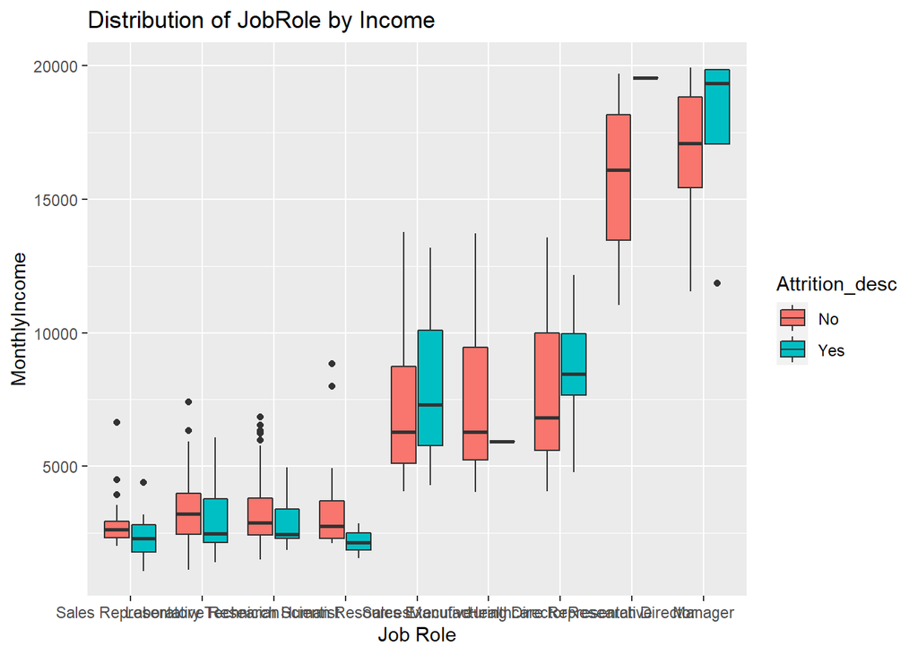

```r
ggplot(df_train, aes(x=factor(JobRole_desc, level=job_role_order), y=MonthlyIncome, fill=Attrition_desc)) + geom_boxplot() + labs(title="Distribution of JobRole by Income", x="Job Role")
```

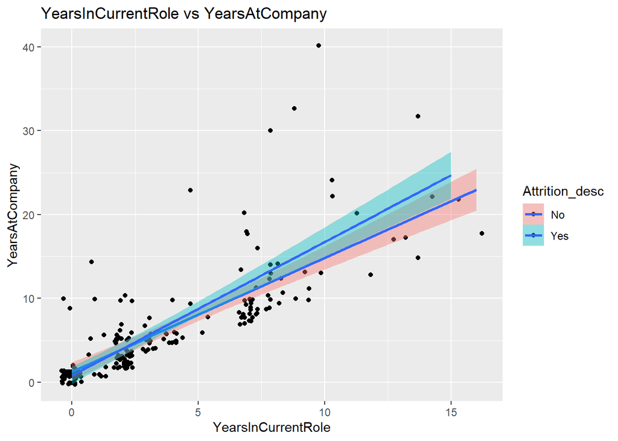

```r
# YearsInCurrentRole vs YearsAtTheCompany
ggplot(df_train_downsampled, aes(x=YearsInCurrentRole, y=YearsAtCompany, fill=Attrition_desc)) + geom_jitter() +geom_smooth(method="lm") + labs(title="YearsInCurrentRole vs YearsAtCompany")
```

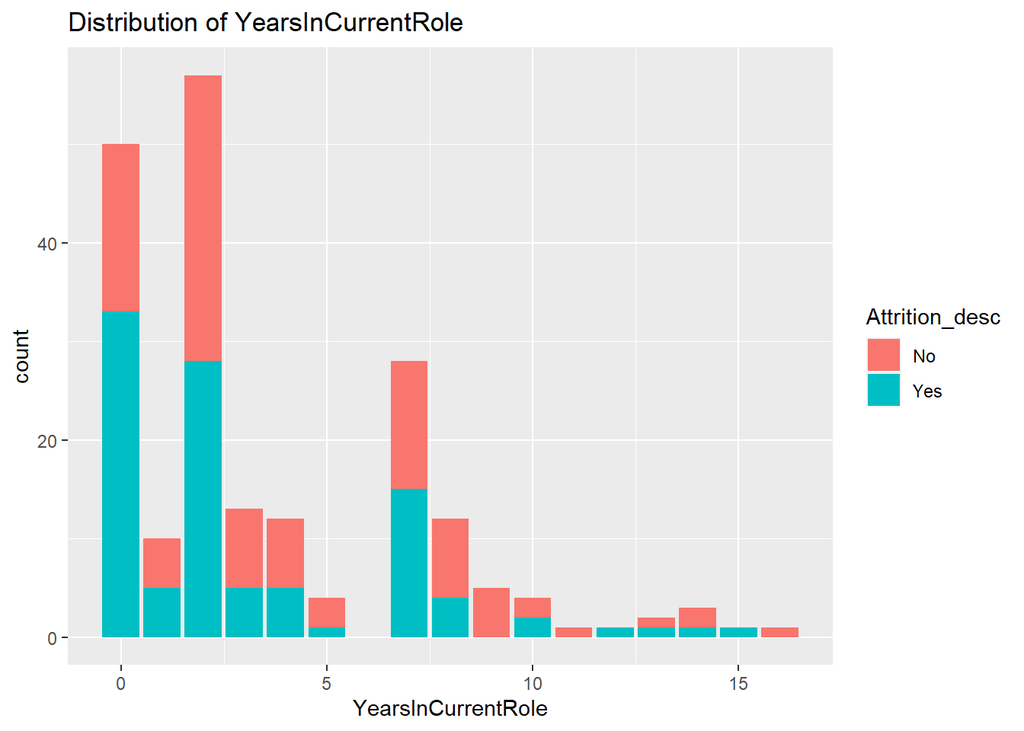

```r
# Distribution of YearsInCurrentRole
ggplot(df_train_downsampled, aes(x=YearsInCurrentRole)) + geom_histogram(stat="count", aes(fill=Attrition_desc)) + labs(title="Distribution of YearsInCurrentRole")
```

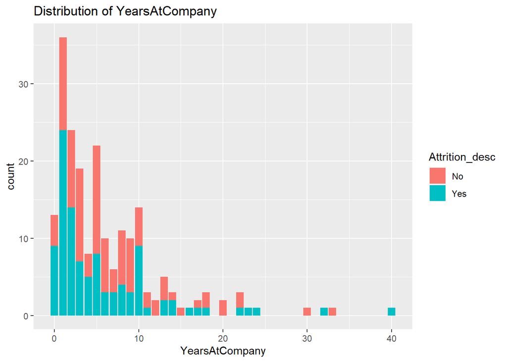

```r
# Distribution of YearsAtCompany
ggplot(df_train_downsampled, aes(x=YearsAtCompany)) + geom_histogram(stat="count", aes(fill=Attrition_desc)) + labs(title="Distribution of YearsAtCompany")
```

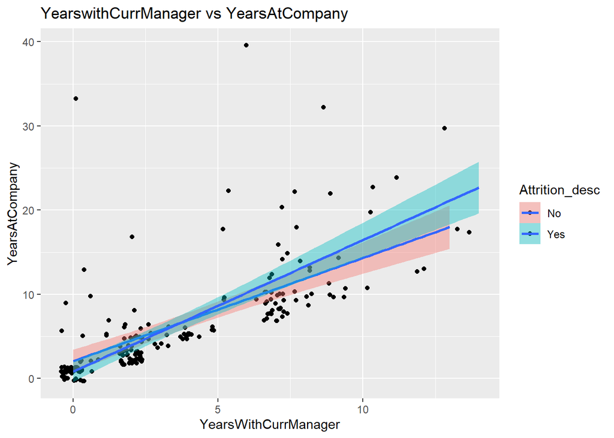

```r
# Relationship between YearswithCurrManager and YearsAtCompany
ggplot(df_train_downsampled, aes(x=YearsWithCurrManager, y=YearsAtCompany,fill=Attrition_desc)) + geom_jitter() +geom_smooth(method="lm") + labs(title="YearswithCurrManager vs YearsAtCompany")
```

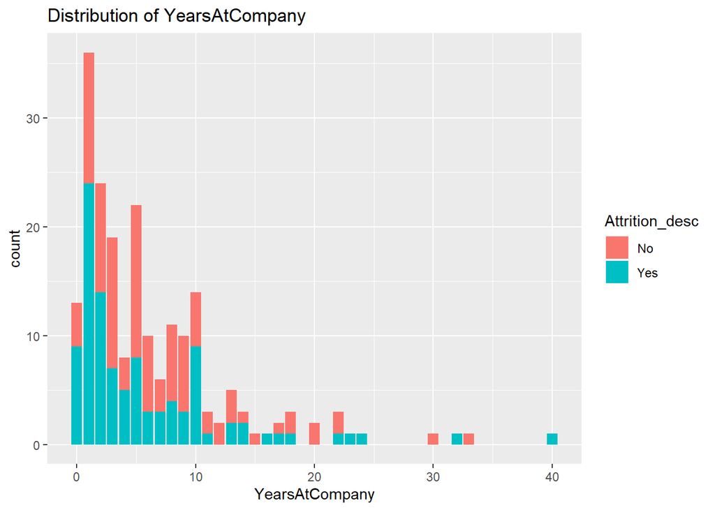

```r
# Distribution of YearsAtCompany
ggplot(df_train_downsampled, aes(x=YearsAtCompany)) + geom_histogram(stat="count", aes(fill=Attrition_desc)) + labs(title="Distribution of YearsAtCompany")
```

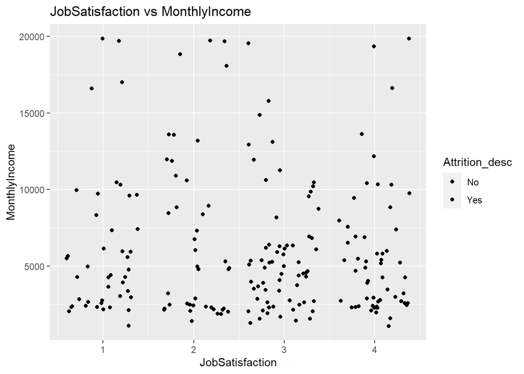

```r
# Evaluating relationship between JobSatisfaction and MonthlyIncome
ggplot(df_train_downsampled, aes(x=JobSatisfaction, y=MonthlyIncome,fill=Attrition_desc)) + geom_jitter() + labs(title="JobSatisfaction vs MonthlyIncome")
```

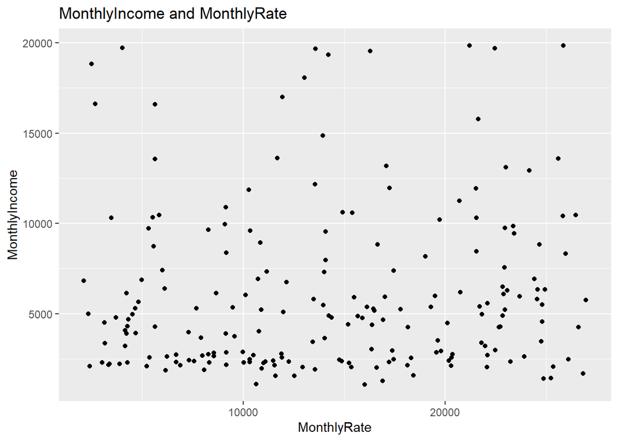

```r
# Evaluating relationship between MonthlyIncome and MonthlyRate
ggplot(df_train_downsampled, aes(x=MonthlyRate, y=MonthlyIncome)) + geom_point() + labs(title="MonthlyIncome and MonthlyRate")
```

```r
# # plotting all numerical variables against response (monthly income)
# num_types_plot <- c(20:45)
# num_types_par <- par(mfrow=c(6,5))
# for(i in num_types_plot){
#   col.name <- colnames(df_final_downsampled[i])
#   plot(df_final_downsampled[,i],df_final_downsampled$MonthlyIncome, xlab=col.name, ylab="Monthly Income")
#
# }
# par(num_types_par)
```

### EDA - Part 2 - Analysis of Categorical Types & ANOVA

**In the second part of our EDA, we wanted to look closer into our categorical variables. From a quick plot of our categorical type variables vs our response variable (attrition) on the downsampled training dataset (due to the aforementioned disporportion of our variable of interest) we can see a few things. First, we see that attrition is somewhat split evenly for most of our categorical variables, though is visual evidence to suggest there are a few variables such as JobRole that have a significant relationships with Attrition. Additionally, we can see that attrition increases as the employee’s marital status shifts in a linear fashion between stages. Another interesting thing to note is that there are higher %’s of attrition among non-exempt (non-salaried) employees.**

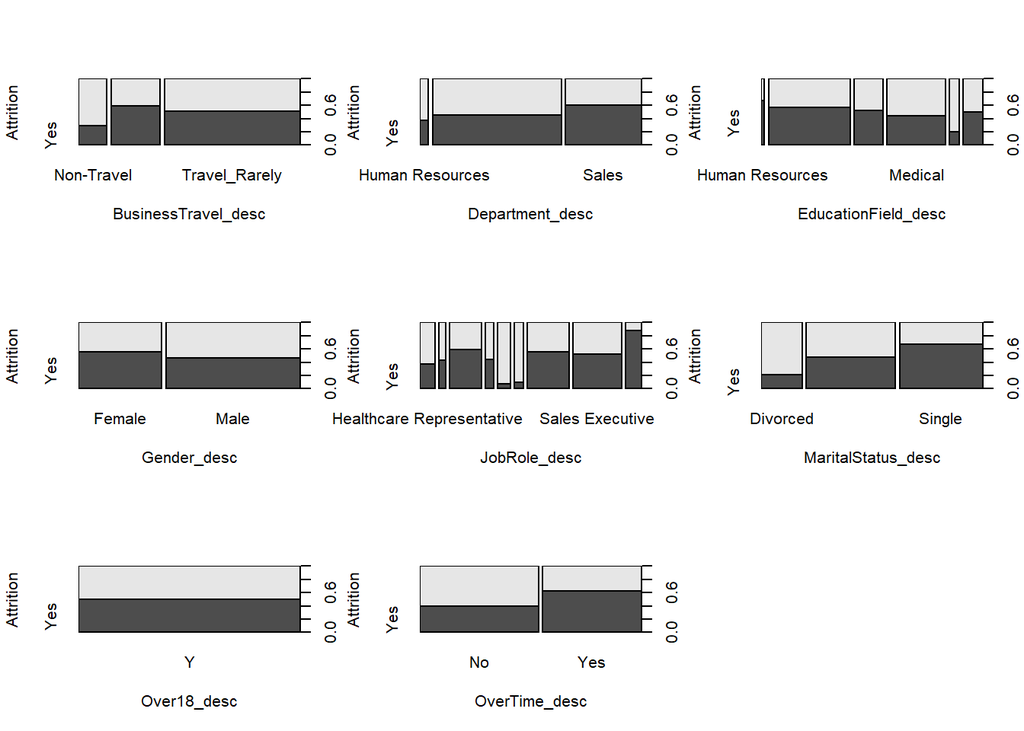

```r
# # plotting our out our Response variable (attrituion) vs our categorical data to assess potential relationships
# grep("_desc", colnames(df_final))
cat_types_plot <- c(5,7,9,11,13,15,17,19)
cat_types_dwnsmpled_par <- par(mfrow=c(3,3))
for(i in cat_types_plot){
  col.name <- colnames(df_train_downsampled[i])
  plot(df_train_downsampled[,i],df_train_downsampled$Attrition_desc, xlab=col.name, ylab="Attrition")
}
par(cat_types_dwnsmpled_par)
```

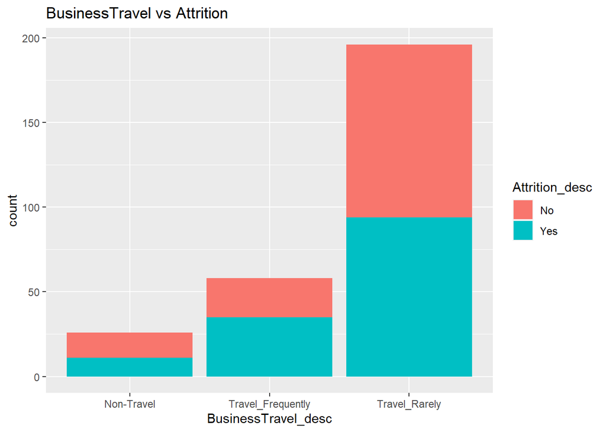

```r
# # looking for differences with categorical variables using ANOVA
# manova_fit_all <- aov(Attrition_ID~., data=df_final_downsampled)
# summary(manova_fit_all)

# Relationship between BusinessTravel and Attrition
df_final_downsampled %>% ggplot(aes(x=BusinessTravel_desc, fill=Attrition_desc)) + geom_bar() + labs(title="BusinessTravel vs Attrition")
```

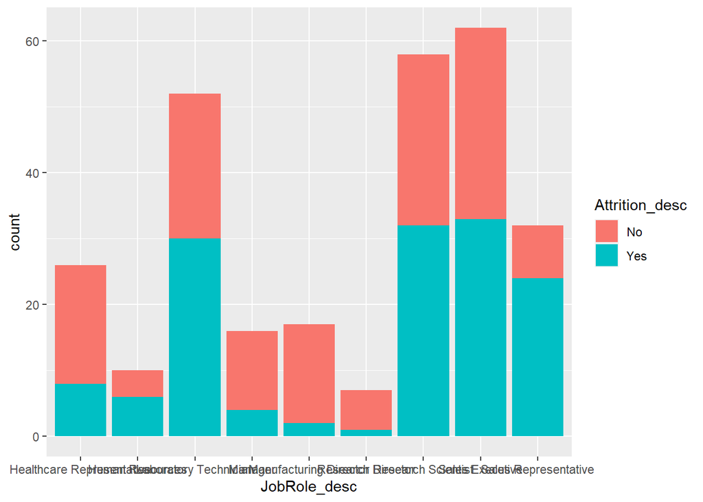

```r
# looking closer into the relationship between JobRole and Attrition.
df_final_downsampled %>% ggplot(aes(x=JobRole_desc)) + geom_histogram(stat="count", aes(fill=Attrition_desc))
```

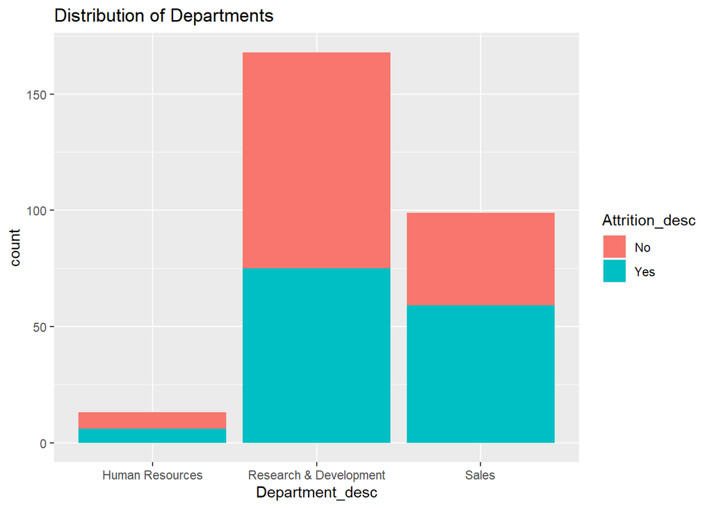

```r
# Distribution of Departments
df_final_downsampled %>% ggplot(aes(x=Department_desc)) + geom_histogram(stat="count", aes(fill=Attrition_desc)) + labs(title="Distribution of Departments")
```

```r
cor(df_final_downsampled$Department_ID,df_final_downsampled$Attrition_ID)
```

```
## [1] 0.1291964
```

### Automated Feature Selection

```r
library(MASS)
# defining variables to exclude based on EDA (removing "_desc" attributes)
exclude_columns_EDA<- c(1,4,5,7,9,11,13,15,16,17,19,24,25,29,35,37,43,45,46)
# removing the EDA based variable reduction to both the downsampled test and train set
full_model_train <- df_train_downsampled[, -exclude_columns_EDA]
full_model_test <- df_test_downsampled[, -exclude_columns_EDA]
# applying EDA based variable reduction to nondownsampeld train and test set
full_model_train_orig <- df_train[, -exclude_columns_EDA]
full_model_test_orig <- df_test_downsampled[, -exclude_columns_EDA]

# Building out our Classification and Linear Regression Model
class_full_model <- lm(Attrition_ID~., data=full_model_train[, -2])
linear_full_model <- lm(MonthlyIncome~., data=full_model_train[, -c(2)])

# stepwise Model
class_step_model <- stepAIC(class_full_model, direction="both", trace=FALSE)
summary(class_step_model)
```

```
##
## Call:
## lm(formula = Attrition_ID ~ Department_ID + MaritalStatus_ID +
##     OverTime_ID + DistanceFromHome + Education + EnvironmentSatisfaction +
##     JobInvolvement + JobSatisfaction + NumCompaniesWorked + PercentSalaryHike +
##     RelationshipSatisfaction + StockOptionLevel + TotalWorkingYears +
##     TrainingTimesLastYear + WorkLifeBalance + YearsSinceLastPromotion,
##     data = full_model_train[, -2])
##
## Residuals:
##      Min       1Q   Median       3Q      Max
## -0.74548 -0.34117 -0.00029  0.27991  0.87860
##
## Coefficients:
##                           Estimate Std. Error t value Pr(>|t|)
## (Intercept)               1.850666   0.311206   5.947 1.32e-08 ***
## Department_ID             0.111461   0.052614   2.118 0.035457 *
## MaritalStatus_ID          0.243526   0.054491   4.469 1.36e-05 ***
## OverTime_ID               0.201625   0.057739   3.492 0.000598 ***
## DistanceFromHome          0.008973   0.003384   2.652 0.008691 **
## Education                -0.051393   0.030567  -1.681 0.094369 .
## EnvironmentSatisfaction  -0.041199   0.025084  -1.642 0.102181
## JobInvolvement           -0.138065   0.038395  -3.596 0.000414 ***
## JobSatisfaction          -0.053257   0.026336  -2.022 0.044577 *
## NumCompaniesWorked        0.019473   0.012162   1.601 0.111039
## PercentSalaryHike        -0.022630   0.008457  -2.676 0.008114 **
## RelationshipSatisfaction -0.038421   0.025827  -1.488 0.138529
## StockOptionLevel          0.070580   0.045763   1.542 0.124689
## TotalWorkingYears        -0.020064   0.004774  -4.203 4.08e-05 ***
## TrainingTimesLastYear    -0.052675   0.023418  -2.249 0.025653 *
## WorkLifeBalance          -0.062173   0.038801  -1.602 0.110765
## YearsSinceLastPromotion   0.038760   0.009959   3.892 0.000138 ***
## ---
## Signif. codes:  0 '***' 0.001 '**' 0.01 '*' 0.05 '.' 0.1 ' ' 1
##
## Residual standard error: 0.3996 on 187 degrees of freedom
## Multiple R-squared:  0.4145, Adjusted R-squared:  0.3644
## F-statistic: 8.274 on 16 and 187 DF,  p-value: 7.131e-15
```

```r
linear_step_model <- stepAIC(linear_full_model, direction="both", trace=FALSE)
summary(linear_step_model)
```

```
##
## Call:
## lm(formula = MonthlyIncome ~ Department_ID + NumCompaniesWorked +
##     RelationshipSatisfaction + TotalWorkingYears + YearsAtCompany +
##     YearsSinceLastPromotion, data = full_model_train[, -c(2)])
##
## Residuals:
##     Min      1Q  Median      3Q     Max
## -8975.0 -1611.9   -45.8  1428.0  9277.7
##
## Coefficients:
##                          Estimate Std. Error t value Pr(>|t|)
## (Intercept)               -761.09    1025.05  -0.742  0.45867
## Department_ID              858.80     365.89   2.347  0.01991 *
## NumCompaniesWorked        -237.83      89.83  -2.647  0.00877 **
## RelationshipSatisfaction   296.64     179.29   1.655  0.09962 .
## TotalWorkingYears          525.75      41.49  12.672  < 2e-16 ***
## YearsAtCompany            -149.20      56.65  -2.634  0.00912 **
## YearsSinceLastPromotion    154.66      82.98   1.864  0.06383 .
## ---
## Signif. codes:  0 '***' 0.001 '**' 0.01 '*' 0.05 '.' 0.1 ' ' 1
##
## Residual standard error: 2829 on 197 degrees of freedom
## Multiple R-squared:   0.62,  Adjusted R-squared:  0.6084
## F-statistic: 53.57 on 6 and 197 DF,  p-value: < 2.2e-16
```

```r
# Forward Model
forward_min <- lm(Attrition_ID~ 1, data=full_model_train[, -2])
class_fwd_model <- step(forward_min, scope=list(lower=forward_min, upper=class_full_model), direction="forward")
```

```
## Start:  AIC=-280.8
## Attrition_ID ~ 1
##
##                            Df Sum of Sq    RSS     AIC
## + MaritalStatus_ID          1    5.8708 45.129 -303.75
## + Age                       1    3.3130 47.687 -292.51
## + JobInvolvement            1    2.7993 48.201 -290.32
## + OverTime_ID               1    2.6135 48.387 -289.54
## + StockOptionLevel          1    2.0193 48.981 -287.05
## + TotalWorkingYears         1    2.0088 48.991 -287.00
## + MonthlyIncome             1    1.8001 49.200 -286.13
## + JobSatisfaction           1    1.4881 49.512 -284.85
## + Department_ID             1    1.1984 49.802 -283.65
## + WorkLifeBalance           1    1.0660 49.934 -283.11
## + EnvironmentSatisfaction   1    0.9973 50.003 -282.83
## + TrainingTimesLastYear     1    0.9487 50.051 -282.63
## + PercentSalaryHike         1    0.9396 50.060 -282.60
## + JobRole_ID                1    0.9136 50.086 -282.49
## + Education                 1    0.8521 50.148 -282.24
## + EducationField_ID         1    0.7077 50.292 -281.65
## + HourlyRate                1    0.6577 50.342 -281.45
## + RelationshipSatisfaction  1    0.5625 50.437 -281.07
## <none>                                  51.000 -280.80
## + DistanceFromHome          1    0.4249 50.575 -280.51
## + YearsAtCompany            1    0.4011 50.599 -280.42
## + Gender_ID                 1    0.3321 50.668 -280.14
## + YearsSinceLastPromotion   1    0.2206 50.779 -279.69
## + MonthlyRate               1    0.1911 50.809 -279.57
## + NumCompaniesWorked        1    0.1204 50.880 -279.29
## + DailyRate                 1    0.0317 50.968 -278.93
##
## Step:  AIC=-303.75
## Attrition_ID ~ MaritalStatus_ID
##
##                            Df Sum of Sq    RSS     AIC
## + JobInvolvement            1   1.98783 43.141 -310.94
## + OverTime_ID               1   1.83899 43.290 -310.24
## + PercentSalaryHike         1   1.65465 43.475 -309.37
## + Age                       1   1.41885 43.710 -308.27
## + JobSatisfaction           1   1.10684 44.022 -306.82
```

[output cut: 370 more lines]

```
##     Department_ID + EnvironmentSatisfaction + WorkLifeBalance +
##     StockOptionLevel + RelationshipSatisfaction + Education +
##     NumCompaniesWorked
##
##                     Df Sum of Sq    RSS     AIC
## <none>                           29.860 -358.01
## + Gender_ID          1  0.283466 29.577 -357.95
## + HourlyRate         1  0.152313 29.708 -357.05
## + MonthlyIncome      1  0.137291 29.723 -356.95
## + Age                1  0.118315 29.742 -356.82
## + DailyRate          1  0.063745 29.796 -356.44
## + MonthlyRate        1  0.026034 29.834 -356.18
## + EducationField_ID  1  0.012575 29.848 -356.09
## + YearsAtCompany     1  0.008690 29.852 -356.06
## + JobRole_ID         1  0.004066 29.856 -356.03
```

```r
summary(class_fwd_model)
```

```
##
## Call:
## lm(formula = Attrition_ID ~ MaritalStatus_ID + JobInvolvement +
##     OverTime_ID + PercentSalaryHike + TotalWorkingYears + YearsSinceLastPromotion +
##     JobSatisfaction + DistanceFromHome + TrainingTimesLastYear +
##     Department_ID + EnvironmentSatisfaction + WorkLifeBalance +
##     StockOptionLevel + RelationshipSatisfaction + Education +
##     NumCompaniesWorked, data = full_model_train[, -2])
##
## Residuals:
##      Min       1Q   Median       3Q      Max
## -0.74548 -0.34117 -0.00029  0.27991  0.87860
##
## Coefficients:
##                           Estimate Std. Error t value Pr(>|t|)
## (Intercept)               1.850666   0.311206   5.947 1.32e-08 ***
## MaritalStatus_ID          0.243526   0.054491   4.469 1.36e-05 ***
## JobInvolvement           -0.138065   0.038395  -3.596 0.000414 ***
## OverTime_ID               0.201625   0.057739   3.492 0.000598 ***
## PercentSalaryHike        -0.022630   0.008457  -2.676 0.008114 **
## TotalWorkingYears        -0.020064   0.004774  -4.203 4.08e-05 ***
## YearsSinceLastPromotion   0.038760   0.009959   3.892 0.000138 ***
## JobSatisfaction          -0.053257   0.026336  -2.022 0.044577 *
## DistanceFromHome          0.008973   0.003384   2.652 0.008691 **
## TrainingTimesLastYear    -0.052675   0.023418  -2.249 0.025653 *
## Department_ID             0.111461   0.052614   2.118 0.035457 *
## EnvironmentSatisfaction  -0.041199   0.025084  -1.642 0.102181
## WorkLifeBalance          -0.062173   0.038801  -1.602 0.110765
## StockOptionLevel          0.070580   0.045763   1.542 0.124689
## RelationshipSatisfaction -0.038421   0.025827  -1.488 0.138529
## Education                -0.051393   0.030567  -1.681 0.094369 .
## NumCompaniesWorked        0.019473   0.012162   1.601 0.111039
## ---
## Signif. codes:  0 '***' 0.001 '**' 0.01 '*' 0.05 '.' 0.1 ' ' 1
##
## Residual standard error: 0.3996 on 187 degrees of freedom
## Multiple R-squared:  0.4145, Adjusted R-squared:  0.3644
## F-statistic: 8.274 on 16 and 187 DF,  p-value: 7.131e-15
```

```r
linear_forward_min <- lm(MonthlyIncome~ 1, data=full_model_train[, -2])
linear_fwd_model <- step(linear_forward_min, scope=list(lower=linear_forward_min, upper=linear_full_model), direction="forward")
```

```
## Start:  AIC=3434.91
## MonthlyIncome ~ 1
##
##                            Df  Sum of Sq        RSS    AIC
## + TotalWorkingYears         1 2434928762 1713999607 3256.6
## + YearsAtCompany            1 1097131572 3051796797 3374.3
## + Age                       1 1094207148 3054721221 3374.5
## + YearsSinceLastPromotion   1  877187108 3271741260 3388.5
## + Attrition_ID              1  146439537 4002488832 3429.6
## + MaritalStatus_ID          1  114808335 4034120034 3431.2
## + DailyRate                 1   85317938 4063610431 3432.7
## + Education                 1   84553706 4064374663 3432.7
## + RelationshipSatisfaction  1   60614455 4088313914 3433.9
## + NumCompaniesWorked        1   55960740 4092967629 3434.1
## + HourlyRate                1   49030339 4099898030 3434.5
## <none>                                   4148928369 3434.9
## + JobRole_ID                1   37103622 4111824747 3435.1
## + Department_ID             1   34498620 4114429749 3435.2
## + EnvironmentSatisfaction   1   31547021 4117381348 3435.4
## + MonthlyRate               1   24278870 4124649499 3435.7
## + JobSatisfaction           1   14197714 4134730655 3436.2
## + StockOptionLevel          1    6204779 4142723590 3436.6
## + Gender_ID                 1    5660854 4143267515 3436.6
## + PercentSalaryHike         1    4389579 4144538790 3436.7
## + OverTime_ID               1    4362250 4144566119 3436.7
## + EducationField_ID         1    3669235 4145259134 3436.7
## + JobInvolvement            1     582611 4148345758 3436.9
## + DistanceFromHome          1     519146 4148409223 3436.9
## + WorkLifeBalance           1     500396 4148427973 3436.9
## + TrainingTimesLastYear     1        570 4148927799 3436.9
##
## Step:  AIC=3256.57
## MonthlyIncome ~ TotalWorkingYears
##
##                            Df Sum of Sq        RSS    AIC
## + Department_ID             1  40730033 1673269574 3253.7
## + NumCompaniesWorked        1  23902024 1690097583 3255.7
## <none>                                  1713999607 3256.6
## + RelationshipSatisfaction  1  13629565 1700370042 3256.9
## + JobRole_ID                1  11569464 1702430143 3257.2
```

[output cut: 143 more lines]

```
## + EnvironmentSatisfaction  1   4526614 1572147221 3250.9
## + MaritalStatus_ID         1   4029178 1572644658 3251.0
## + JobRole_ID               1   3777816 1572896020 3251.0
## + TrainingTimesLastYear    1   3418483 1573255353 3251.1
## + MonthlyRate              1   1948280 1574725556 3251.3
## + OverTime_ID              1   1851539 1574822296 3251.3
## + EducationField_ID        1    999065 1575674771 3251.4
## + JobInvolvement           1    716536 1575957300 3251.4
## + StockOptionLevel         1    500401 1576173435 3251.5
## + JobSatisfaction          1    419142 1576254693 3251.5
## + Gender_ID                1    280218 1576393618 3251.5
## + Education                1    246287 1576427549 3251.5
## + DistanceFromHome         1     35243 1576638593 3251.5
## + Age                      1     21129 1576652707 3251.5
## + PercentSalaryHike        1     19063 1576654772 3251.5
```

```r
summary(linear_fwd_model)
```

```
##
## Call:
## lm(formula = MonthlyIncome ~ TotalWorkingYears + Department_ID +
##     NumCompaniesWorked + YearsAtCompany + YearsSinceLastPromotion +
##     RelationshipSatisfaction, data = full_model_train[, -2])
##
## Residuals:
##     Min      1Q  Median      3Q     Max
## -8975.0 -1611.9   -45.8  1428.0  9277.7
##
## Coefficients:
##                          Estimate Std. Error t value Pr(>|t|)
## (Intercept)               -761.09    1025.05  -0.742  0.45867
## TotalWorkingYears          525.75      41.49  12.672  < 2e-16 ***
## Department_ID              858.80     365.89   2.347  0.01991 *
## NumCompaniesWorked        -237.83      89.83  -2.647  0.00877 **
## YearsAtCompany            -149.20      56.65  -2.634  0.00912 **
## YearsSinceLastPromotion    154.66      82.98   1.864  0.06383 .
## RelationshipSatisfaction   296.64     179.29   1.655  0.09962 .
## ---
## Signif. codes:  0 '***' 0.001 '**' 0.01 '*' 0.05 '.' 0.1 ' ' 1
##
## Residual standard error: 2829 on 197 degrees of freedom
## Multiple R-squared:   0.62,  Adjusted R-squared:  0.6084
## F-statistic: 53.57 on 6 and 197 DF,  p-value: < 2.2e-16
```

```r
# Backward Model
class_bck_model <- stepAIC(class_full_model, direction="backward", trace=FALSE)
summary(class_bck_model)
```

```
##
## Call:
## lm(formula = Attrition_ID ~ Department_ID + MaritalStatus_ID +
##     OverTime_ID + DistanceFromHome + Education + EnvironmentSatisfaction +
##     JobInvolvement + JobSatisfaction + NumCompaniesWorked + PercentSalaryHike +
##     RelationshipSatisfaction + StockOptionLevel + TotalWorkingYears +
##     TrainingTimesLastYear + WorkLifeBalance + YearsSinceLastPromotion,
##     data = full_model_train[, -2])
##
## Residuals:
##      Min       1Q   Median       3Q      Max
## -0.74548 -0.34117 -0.00029  0.27991  0.87860
##
## Coefficients:
##                           Estimate Std. Error t value Pr(>|t|)
## (Intercept)               1.850666   0.311206   5.947 1.32e-08 ***
## Department_ID             0.111461   0.052614   2.118 0.035457 *
## MaritalStatus_ID          0.243526   0.054491   4.469 1.36e-05 ***
## OverTime_ID               0.201625   0.057739   3.492 0.000598 ***
## DistanceFromHome          0.008973   0.003384   2.652 0.008691 **
## Education                -0.051393   0.030567  -1.681 0.094369 .
## EnvironmentSatisfaction  -0.041199   0.025084  -1.642 0.102181
## JobInvolvement           -0.138065   0.038395  -3.596 0.000414 ***
## JobSatisfaction          -0.053257   0.026336  -2.022 0.044577 *
## NumCompaniesWorked        0.019473   0.012162   1.601 0.111039
## PercentSalaryHike        -0.022630   0.008457  -2.676 0.008114 **
## RelationshipSatisfaction -0.038421   0.025827  -1.488 0.138529
## StockOptionLevel          0.070580   0.045763   1.542 0.124689
## TotalWorkingYears        -0.020064   0.004774  -4.203 4.08e-05 ***
## TrainingTimesLastYear    -0.052675   0.023418  -2.249 0.025653 *
## WorkLifeBalance          -0.062173   0.038801  -1.602 0.110765
## YearsSinceLastPromotion   0.038760   0.009959   3.892 0.000138 ***
## ---
## Signif. codes:  0 '***' 0.001 '**' 0.01 '*' 0.05 '.' 0.1 ' ' 1
##
## Residual standard error: 0.3996 on 187 degrees of freedom
## Multiple R-squared:  0.4145, Adjusted R-squared:  0.3644
## F-statistic: 8.274 on 16 and 187 DF,  p-value: 7.131e-15
```

```r
linear_bck_model <- stepAIC(linear_full_model, direction="backward", trace=FALSE)
summary(linear_bck_model)
```

```
##
## Call:
## lm(formula = MonthlyIncome ~ Department_ID + NumCompaniesWorked +
##     RelationshipSatisfaction + TotalWorkingYears + YearsAtCompany +
##     YearsSinceLastPromotion, data = full_model_train[, -c(2)])
##
## Residuals:
##     Min      1Q  Median      3Q     Max
## -8975.0 -1611.9   -45.8  1428.0  9277.7
##
## Coefficients:
##                          Estimate Std. Error t value Pr(>|t|)
## (Intercept)               -761.09    1025.05  -0.742  0.45867
## Department_ID              858.80     365.89   2.347  0.01991 *
## NumCompaniesWorked        -237.83      89.83  -2.647  0.00877 **
## RelationshipSatisfaction   296.64     179.29   1.655  0.09962 .
## TotalWorkingYears          525.75      41.49  12.672  < 2e-16 ***
## YearsAtCompany            -149.20      56.65  -2.634  0.00912 **
## YearsSinceLastPromotion    154.66      82.98   1.864  0.06383 .
## ---
## Signif. codes:  0 '***' 0.001 '**' 0.01 '*' 0.05 '.' 0.1 ' ' 1
##
## Residual standard error: 2829 on 197 degrees of freedom
## Multiple R-squared:   0.62,  Adjusted R-squared:  0.6084
## F-statistic: 53.57 on 6 and 197 DF,  p-value: < 2.2e-16
```

```r
# For Classification Model: defining variables to exclude based on EDA (+ removing "_desc" attributes)
exclude_columns_featureselect<- c(4,5,6,9,10,14,17,18,26)
# For Classification Model: applying EDA based attribute reduction to nondownsampeld train and test set
reduced_model_train_orig <- full_model_train_orig[, -exclude_columns_featureselect]
reduced_model_test_orig <- full_model_test_orig[, -exclude_columns_featureselect]
# For Classification Model: removing the EDA based attributes to both the downsampled test and train set
reduced_model_train <- full_model_train[, -exclude_columns_featureselect]
reduced_model_test <- full_model_test[, -exclude_columns_featureselect]

# For Linear Regression Model: defining variables to exclude based on EDA (+ removing "_desc" attributes)
exclude_columns_featureselect_linear <- c(4,5,6,9,10,14,18,26)
# For Linear Regression Model using automated feature select
exclude_columns_featureselect_linear_auto <- c(1,2,4,5,6,7,8,9,10,11,12,13,14,15,16,18,22,24,25)
# For Linear Regression Model: removing the EDA based variable reduction to both the downsampled test and train set
reduced_model_train_linear <- full_model_train[, -exclude_columns_featureselect_linear]
reduced_model_test_linear <- full_model_test[, -exclude_columns_featureselect_linear]
# For Linear Regression Model: removing automated feature select based variable reduction to both the downsampled test and train set
reduced_model_train_linear_auto <- full_model_train[, -exclude_columns_featureselect_linear_auto]
reduced_model_test_linear_auto <- full_model_test[, -exclude_columns_featureselect_linear_auto]

# identifying top factors for Attrition
manova_fit_all <- aov(Attrition_ID~.,data=reduced_model_train_orig[,-2])
summary(manova_fit_all)
```

```
##                           Df Sum Sq Mean Sq F value   Pr(>F)
## Department_ID              1   1.02   1.023   9.725 0.001906 **
## MaritalStatus_ID           1   3.69   3.688  35.051 5.44e-09 ***
## OverTime_ID                1   6.15   6.153  58.470 8.39e-14 ***
## DistanceFromHome           1   0.98   0.977   9.283 0.002415 **
## Education                  1   0.71   0.711   6.754 0.009586 **
## EnvironmentSatisfaction    1   0.57   0.570   5.417 0.020277 *
## JobInvolvement             1   2.72   2.717  25.821 5.03e-07 ***
## JobSatisfaction            1   1.27   1.265  12.025 0.000563 ***
## NumCompaniesWorked         1   0.37   0.368   3.495 0.062048 .
## PercentSalaryHike          1   0.12   0.117   1.109 0.292722
## RelationshipSatisfaction   1   0.57   0.572   5.440 0.020013 *
## StockOptionLevel           1   0.00   0.002   0.021 0.885063
## TotalWorkingYears          1   1.69   1.691  16.068 6.89e-05 ***
## TrainingTimesLastYear      1   0.61   0.609   5.789 0.016433 *
## WorkLifeBalance            1   0.44   0.437   4.153 0.042011 *
## YearsSinceLastPromotion    1   1.72   1.718  16.330 6.02e-05 ***
## Residuals                592  62.30   0.105
## ---
## Signif. codes:  0 '***' 0.001 '**' 0.01 '*' 0.05 '.' 0.1 ' ' 1
```

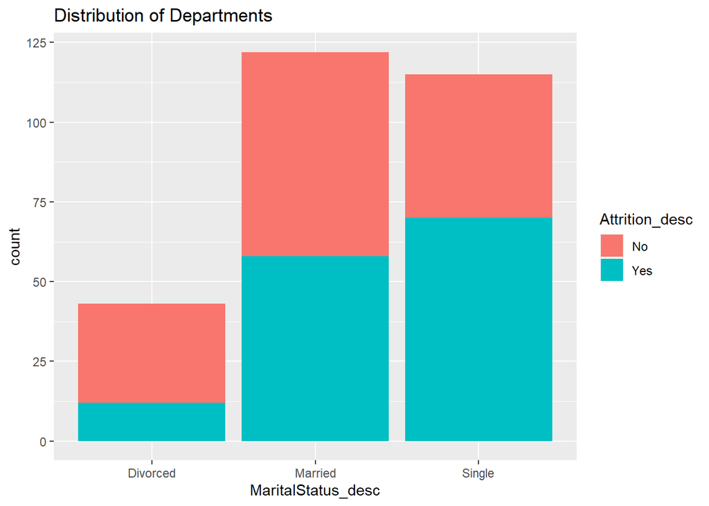

```r
df_final_downsampled %>% ggplot(aes(x=MaritalStatus_desc, fill=Attrition_desc)) + geom_bar() + labs(title="Distribution of Departments")
```

### Classification Model - Logistic Regression

```r
# Logistic Regression Model
library(glmnet)
logit_model_downsampled <- glm(Attrition_desc~., family="binomial", data=full_model_train[, -1])
summary(logit_model_downsampled)
```

```
##
## Call:
## glm(formula = Attrition_desc ~ ., family = "binomial", data = full_model_train[,
##     -1])
##
## Deviance Residuals:
##      Min        1Q    Median        3Q       Max
## -1.95953  -0.64694   0.01834   0.59181   2.71142
##
## Coefficients:
##                            Estimate Std. Error z value Pr(>|z|)
## (Intercept)               4.167e+00  2.854e+00   1.460  0.14427
## Department_ID             1.022e+00  5.446e-01   1.877  0.06051 .
## EducationField_ID        -7.227e-02  1.496e-01  -0.483  0.62910
## Gender_ID                -7.562e-01  4.307e-01  -1.756  0.07913 .
## JobRole_ID               -3.716e-02  1.119e-01  -0.332  0.73990
## MaritalStatus_ID          1.585e+00  4.403e-01   3.599  0.00032 ***
## OverTime_ID               1.202e+00  4.189e-01   2.870  0.00410 **
## Age                      -2.986e-02  3.329e-02  -0.897  0.36961
## DailyRate                -2.776e-04  5.358e-04  -0.518  0.60442
## DistanceFromHome          7.050e-02  2.571e-02   2.742  0.00610 **
## Education                -4.889e-01  2.187e-01  -2.235  0.02541 *
## EnvironmentSatisfaction  -2.958e-01  1.793e-01  -1.650  0.09901 .
## HourlyRate                1.276e-02  1.089e-02   1.172  0.24134
## JobInvolvement           -9.212e-01  2.879e-01  -3.200  0.00137 **
## JobSatisfaction          -2.741e-01  1.954e-01  -1.402  0.16083
## MonthlyIncome            -7.212e-05  7.666e-05  -0.941  0.34683
## MonthlyRate              -2.519e-06  2.864e-05  -0.088  0.92991
## NumCompaniesWorked        1.908e-01  1.023e-01   1.866  0.06211 .
## PercentSalaryHike        -1.547e-01  6.329e-02  -2.444  0.01452 *
## RelationshipSatisfaction -1.656e-01  1.835e-01  -0.903  0.36664
## StockOptionLevel          5.684e-01  3.239e-01   1.755  0.07930 .
## TotalWorkingYears        -1.022e-01  7.062e-02  -1.447  0.14796
## TrainingTimesLastYear    -3.848e-01  1.724e-01  -2.231  0.02565 *
## WorkLifeBalance          -5.100e-01  2.858e-01  -1.784  0.07440 .
## YearsAtCompany           -2.248e-03  6.489e-02  -0.035  0.97237
## YearsSinceLastPromotion   3.095e-01  9.641e-02   3.210  0.00133 **
## ---
## Signif. codes:  0 '***' 0.001 '**' 0.01 '*' 0.05 '.' 0.1 ' ' 1
##
## (Dispersion parameter for binomial family taken to be 1)
##
##     Null deviance: 282.80  on 203  degrees of freedom
## Residual deviance: 169.29  on 178  degrees of freedom
## AIC: 221.29
##
## Number of Fisher Scoring iterations: 6
```

```r
logit_model_orig<- glm(Attrition_desc~., family="binomial", data=full_model_train_orig[, -1])
summary(logit_model_orig)
```

```
##
## Call:
## glm(formula = Attrition_desc ~ ., family = "binomial", data = full_model_train_orig[,
##     -1])
##
## Deviance Residuals:
##     Min       1Q   Median       3Q      Max
## -1.8122  -0.4852  -0.2492  -0.0842   3.1974
##
## Coefficients:
##                            Estimate Std. Error z value Pr(>|z|)
## (Intercept)               2.809e+00  1.877e+00   1.497 0.134435
## Department_ID             6.555e-01  4.052e-01   1.618 0.105708
## EducationField_ID        -1.856e-01  1.091e-01  -1.701 0.088939 .
## Gender_ID                -8.642e-02  2.833e-01  -0.305 0.760304
## JobRole_ID               -3.152e-02  8.371e-02  -0.377 0.706482
## MaritalStatus_ID          1.009e+00  2.882e-01   3.501 0.000463 ***
## OverTime_ID               1.828e+00  2.954e-01   6.188 6.10e-10 ***
## Age                      -5.637e-02  2.281e-02  -2.472 0.013444 *
## DailyRate                -2.119e-04  3.539e-04  -0.599 0.549277
## DistanceFromHome          5.321e-02  1.671e-02   3.185 0.001449 **
## Education                -2.654e-01  1.434e-01  -1.851 0.064224 .
## EnvironmentSatisfaction  -2.696e-01  1.265e-01  -2.130 0.033132 *
## HourlyRate                1.205e-02  7.064e-03   1.706 0.088091 .
## JobInvolvement           -9.894e-01  1.985e-01  -4.984 6.23e-07 ***
## JobSatisfaction          -3.946e-01  1.287e-01  -3.065 0.002176 **
## MonthlyIncome            -4.028e-05  5.762e-05  -0.699 0.484504
## MonthlyRate              -2.512e-05  2.011e-05  -1.249 0.211651
## NumCompaniesWorked        2.127e-01  6.486e-02   3.280 0.001038 **
## PercentSalaryHike        -5.587e-02  4.122e-02  -1.355 0.175339
## RelationshipSatisfaction -2.421e-01  1.255e-01  -1.929 0.053726 .
## StockOptionLevel          1.042e-01  2.353e-01   0.443 0.657949
## TotalWorkingYears        -7.819e-02  4.520e-02  -1.730 0.083629 .
## TrainingTimesLastYear    -2.779e-01  1.176e-01  -2.364 0.018099 *
## WorkLifeBalance          -5.018e-01  1.880e-01  -2.670 0.007592 **
## YearsAtCompany           -4.356e-02  4.594e-02  -0.948 0.343037
## YearsSinceLastPromotion   2.651e-01  6.325e-02   4.191 2.78e-05 ***
## ---
## Signif. codes:  0 '***' 0.001 '**' 0.01 '*' 0.05 '.' 0.1 ' ' 1
##
## (Dispersion parameter for binomial family taken to be 1)
##
##     Null deviance: 550.39  on 608  degrees of freedom
## Residual deviance: 352.13  on 583  degrees of freedom
## AIC: 404.13
##
## Number of Fisher Scoring iterations: 6
```

```r
logit_model_reduced <- glm(Attrition_desc~., family="binomial", data=reduced_model_train_orig[, -1])
summary(logit_model_reduced)
```

```
##
## Call:
## glm(formula = Attrition_desc ~ ., family = "binomial", data = reduced_model_train_orig[,
##     -1])
##
## Deviance Residuals:
##     Min       1Q   Median       3Q      Max
## -1.7745  -0.4900  -0.2730  -0.1084   3.3670
##
## Coefficients:
##                          Estimate Std. Error z value Pr(>|z|)
## (Intercept)               0.81963    1.50759   0.544 0.586669
## Department_ID             0.51970    0.26001   1.999 0.045636 *
## MaritalStatus_ID          1.07387    0.27946   3.843 0.000122 ***
## OverTime_ID               1.77370    0.28534   6.216 5.10e-10 ***
## DistanceFromHome          0.05253    0.01640   3.203 0.001361 **
## Education                -0.30398    0.13779  -2.206 0.027378 *
## EnvironmentSatisfaction  -0.29273    0.12197  -2.400 0.016394 *
## JobInvolvement           -0.92567    0.18984  -4.876 1.08e-06 ***
## JobSatisfaction          -0.42498    0.12375  -3.434 0.000595 ***
## NumCompaniesWorked        0.20894    0.05864   3.563 0.000367 ***
## PercentSalaryHike        -0.05175    0.04011  -1.290 0.196991
## RelationshipSatisfaction -0.27551    0.12133  -2.271 0.023164 *
## StockOptionLevel          0.14964    0.22629   0.661 0.508448
## TotalWorkingYears        -0.15572    0.02972  -5.240 1.61e-07 ***
## TrainingTimesLastYear    -0.26941    0.11358  -2.372 0.017694 *
## WorkLifeBalance          -0.49305    0.18378  -2.683 0.007301 **
## YearsSinceLastPromotion   0.23986    0.05349   4.484 7.31e-06 ***
## ---
## Signif. codes:  0 '***' 0.001 '**' 0.01 '*' 0.05 '.' 0.1 ' ' 1
##
## (Dispersion parameter for binomial family taken to be 1)
##
##     Null deviance: 550.39  on 608  degrees of freedom
## Residual deviance: 365.77  on 592  degrees of freedom
## AIC: 399.77
##
## Number of Fisher Scoring iterations: 6
```

```r
#determing accuracy of logitic regression model
logit_pred_downsampled <- predict(logit_model_downsampled, newdata=full_model_test, type="response")
logit_pred_orig <- predict(logit_model_orig, newdata=full_model_test_orig, type="response")

logit_pred_reduced <- predict(logit_model_reduced, newdata=reduced_model_test, type="response")

cutoff <- .5
logit_pred_downsampled.class <- factor(ifelse(logit_pred_downsampled>cutoff, "yes", "no"))
logit_pred_orig.class <- factor(ifelse(logit_pred_orig>cutoff, "yes", "no"))
logit_pred_reduced.class <- factor(ifelse(logit_pred_reduced>cutoff, "yes", "no"))

# converting Attrition values to lower case to match with prediction factors
full_model_test$Attrition_desc <- tolower(full_model_test$Attrition_desc)
full_model_test_orig$Attrition_desc <- tolower(full_model_test_orig$Attrition_desc)
reduced_model_test$Attrition_desc <- tolower(reduced_model_test$Attrition_desc)

# confusion matrix for logistic regression accuracy
confusionMatrix(logit_pred_downsampled.class, as.factor(full_model_test$Attrition_desc))
```

```
## Confusion Matrix and Statistics
##
##           Reference
## Prediction no yes
##        no  28  19
##        yes 10  19
##
##                Accuracy : 0.6184
##                  95% CI : (0.4998, 0.7275)
##     No Information Rate : 0.5
##     P-Value [Acc > NIR] : 0.02523
##
##                   Kappa : 0.2368
##
##  Mcnemar's Test P-Value : 0.13739
##
##             Sensitivity : 0.7368
##             Specificity : 0.5000
##          Pos Pred Value : 0.5957
##          Neg Pred Value : 0.6552
##              Prevalence : 0.5000
##          Detection Rate : 0.3684
##    Detection Prevalence : 0.6184
##       Balanced Accuracy : 0.6184
##
##        'Positive' Class : no
##
```

```r
confusionMatrix(logit_pred_orig.class, as.factor(full_model_test_orig$Attrition_desc))
```

```
## Confusion Matrix and Statistics
##
##           Reference
## Prediction no yes
##        no  36  26
##        yes  2  12
##
##                Accuracy : 0.6316
##                  95% CI : (0.5131, 0.7394)
##     No Information Rate : 0.5
##     P-Value [Acc > NIR] : 0.01431
##
##                   Kappa : 0.2632
##
##  Mcnemar's Test P-Value : 1.383e-05
##
##             Sensitivity : 0.9474
##             Specificity : 0.3158
##          Pos Pred Value : 0.5806
##          Neg Pred Value : 0.8571
##              Prevalence : 0.5000
##          Detection Rate : 0.4737
##    Detection Prevalence : 0.8158
##       Balanced Accuracy : 0.6316
##
##        'Positive' Class : no
##
```

```r
confusionMatrix(logit_pred_reduced.class, as.factor(reduced_model_test$Attrition_desc))
```

```
## Confusion Matrix and Statistics
##
##           Reference
## Prediction no yes
##        no  35  23
##        yes  3  15
##
##                Accuracy : 0.6579
##                  95% CI : (0.5401, 0.7629)
##     No Information Rate : 0.5
##     P-Value [Acc > NIR] : 0.0039526
##
##                   Kappa : 0.3158
##
##  Mcnemar's Test P-Value : 0.0001944
##
##             Sensitivity : 0.9211
##             Specificity : 0.3947
##          Pos Pred Value : 0.6034
##          Neg Pred Value : 0.8333
##              Prevalence : 0.5000
##          Detection Rate : 0.4605
##    Detection Prevalence : 0.7632
##       Balanced Accuracy : 0.6579
##
##        'Positive' Class : no
##
```

### Classification Model - kNN

```r
library(class) # for knn
reduced_model_train_knn <- reduced_model_train[,-2]
reduced_model_test_knn <- reduced_model_test[,-2]

knn_classification <- knn(reduced_model_train_knn,reduced_model_test_knn, reduced_model_train_knn$Attrition_ID,prob = TRUE, k = 5)
knn_reduced_model_confusionMatrix <- confusionMatrix(table(knn_classification,reduced_model_test_knn$Attrition_ID))
knn_reduced_model_confusionMatrix
```

```
## Confusion Matrix and Statistics
##
##
## knn_classification  1  2
##                  1 27 14
##                  2 11 24
##
##                Accuracy : 0.6711
##                  95% CI : (0.5537, 0.7746)
##     No Information Rate : 0.5
##     P-Value [Acc > NIR] : 0.001918
##
##                   Kappa : 0.3421
##
##  Mcnemar's Test P-Value : 0.689157
##
##             Sensitivity : 0.7105
##             Specificity : 0.6316
##          Pos Pred Value : 0.6585
##          Neg Pred Value : 0.6857
##              Prevalence : 0.5000
##          Detection Rate : 0.3553
##    Detection Prevalence : 0.5395
##       Balanced Accuracy : 0.6711
##
##        'Positive' Class : 1
##
```

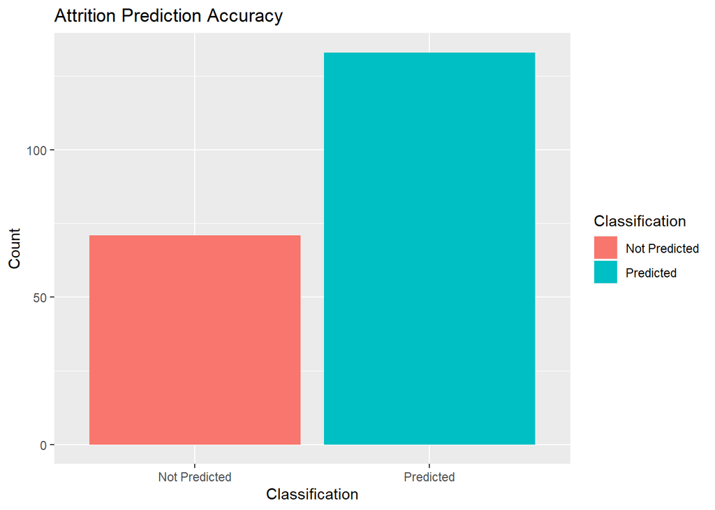

```r
knn_comp <- reduced_model_train_knn
knn_comp$pred_value <- knn.cv(reduced_model_train_knn,reduced_model_train_knn$Attrition_ID,prob = TRUE, k = 5)


knn_tbl <- knn_comp %>% group_by(pred_value, Attrition_ID) %>% tally()
knn_tbl$Classification <- ifelse(knn_tbl$pred_value ==knn_tbl$Attrition_ID, "Predicted", "Not Predicted")
knn_tbl %>% ggplot(aes(x=Classification,y=n, fill= Classification)) + geom_bar(stat="identity")+
  labs(y="Count", title="Attrition Prediction Accuracy")
```

### Linear Regression Model

**The linear model was done using a simple linear regression approach. The linear regression model was applied 3 times, once with the EDA full model, another with a reduced model with EDA and automated feature selection applied, and lastly a model solely based on feature selected explanatory variables alone. One thing to note here is that using feature selection, it vastly reduced the variable set applied during EDA, this could be explained as feature selection removing variables that were not significant to predicting Salary (MonthlyIncome) that was significat to predicting Attrition. Once all 3 linear regression models were created, we outputed the prediction and compared them using RMSE as the metric comparison. We found that though the full model had the lowest RMSE (prediction variance), it could be more susceptible to overfitting and so the 2nd RMSE model which utilized a reduced model based on auto feature selection was chosen as our optimal linear regression model.**

```r
# linear regression based on our EDA full model
linear_regression_model_full <- lm(MonthlyIncome~., data=full_model_train[, -c(2)])
summary(linear_regression_model_full)
```

```
##
## Call:
## lm(formula = MonthlyIncome ~ ., data = full_model_train[, -c(2)])
##
## Residuals:
##    Min     1Q Median     3Q    Max
##  -8287  -1491   -127   1518   8605
##
## Coefficients:
##                            Estimate Std. Error t value Pr(>|t|)
## (Intercept)               1.442e+03  2.986e+03   0.483   0.6297
## Attrition_ID             -5.312e+02  5.425e+02  -0.979   0.3288
## Department_ID             1.181e+03  5.549e+02   2.129   0.0346 *
## EducationField_ID         3.217e+01  1.598e+02   0.201   0.8407
## Gender_ID                -1.271e+01  4.437e+02  -0.029   0.9772
## JobRole_ID               -9.100e+01  1.214e+02  -0.749   0.4546
## MaritalStatus_ID         -3.894e+02  4.330e+02  -0.899   0.3697
## OverTime_ID              -4.076e+01  4.413e+02  -0.092   0.9265
## Age                      -7.948e+00  3.228e+01  -0.246   0.8058
## DailyRate                 3.652e-01  5.546e-01   0.658   0.5111
## DistanceFromHome          3.319e+00  2.561e+01   0.130   0.8970
## Education                 4.201e+01  2.296e+02   0.183   0.8550
## EnvironmentSatisfaction  -1.565e+02  1.884e+02  -0.831   0.4072
## HourlyRate                9.202e+00  1.142e+01   0.806   0.4213
## JobInvolvement            4.174e+01  2.982e+02   0.140   0.8888
## JobSatisfaction          -6.800e+01  2.019e+02  -0.337   0.7366
## MonthlyRate               9.709e-03  3.118e-02   0.311   0.7558
## NumCompaniesWorked       -2.268e+02  9.938e+01  -2.282   0.0237 *
## PercentSalaryHike         2.075e+00  6.334e+01   0.033   0.9739
## RelationshipSatisfaction  2.968e+02  1.941e+02   1.530   0.1279
## StockOptionLevel         -2.820e+02  3.459e+02  -0.815   0.4159
## TotalWorkingYears         5.037e+02  5.487e+01   9.181   <2e-16 ***
## TrainingTimesLastYear    -1.220e+02  1.755e+02  -0.695   0.4881
## WorkLifeBalance          -2.096e+02  2.929e+02  -0.716   0.4752
## YearsAtCompany           -1.459e+02  6.077e+01  -2.401   0.0174 *
## YearsSinceLastPromotion   1.639e+02  9.169e+01   1.788   0.0755 .
## ---
## Signif. codes:  0 '***' 0.001 '**' 0.01 '*' 0.05 '.' 0.1 ' ' 1
##
## Residual standard error: 2925 on 178 degrees of freedom
## Multiple R-squared:  0.6331, Adjusted R-squared:  0.5815
## F-statistic: 12.28 on 25 and 178 DF,  p-value: < 2.2e-16
```

```r
# linear regression based on our EDA + Automated Feature Selection model
linear_regression_model_reduced <- lm(MonthlyIncome~., data=reduced_model_train_linear)
summary(linear_regression_model_full)
```

```
##
## Call:
## lm(formula = MonthlyIncome ~ ., data = full_model_train[, -c(2)])
##
## Residuals:
##    Min     1Q Median     3Q    Max
##  -8287  -1491   -127   1518   8605
##
## Coefficients:
##                            Estimate Std. Error t value Pr(>|t|)
## (Intercept)               1.442e+03  2.986e+03   0.483   0.6297
## Attrition_ID             -5.312e+02  5.425e+02  -0.979   0.3288
## Department_ID             1.181e+03  5.549e+02   2.129   0.0346 *
## EducationField_ID         3.217e+01  1.598e+02   0.201   0.8407
## Gender_ID                -1.271e+01  4.437e+02  -0.029   0.9772
## JobRole_ID               -9.100e+01  1.214e+02  -0.749   0.4546
## MaritalStatus_ID         -3.894e+02  4.330e+02  -0.899   0.3697
## OverTime_ID              -4.076e+01  4.413e+02  -0.092   0.9265
## Age                      -7.948e+00  3.228e+01  -0.246   0.8058
## DailyRate                 3.652e-01  5.546e-01   0.658   0.5111
## DistanceFromHome          3.319e+00  2.561e+01   0.130   0.8970
## Education                 4.201e+01  2.296e+02   0.183   0.8550
## EnvironmentSatisfaction  -1.565e+02  1.884e+02  -0.831   0.4072
## HourlyRate                9.202e+00  1.142e+01   0.806   0.4213
## JobInvolvement            4.174e+01  2.982e+02   0.140   0.8888
## JobSatisfaction          -6.800e+01  2.019e+02  -0.337   0.7366
## MonthlyRate               9.709e-03  3.118e-02   0.311   0.7558
## NumCompaniesWorked       -2.268e+02  9.938e+01  -2.282   0.0237 *
## PercentSalaryHike         2.075e+00  6.334e+01   0.033   0.9739
## RelationshipSatisfaction  2.968e+02  1.941e+02   1.530   0.1279
## StockOptionLevel         -2.820e+02  3.459e+02  -0.815   0.4159
## TotalWorkingYears         5.037e+02  5.487e+01   9.181   <2e-16 ***
## TrainingTimesLastYear    -1.220e+02  1.755e+02  -0.695   0.4881
## WorkLifeBalance          -2.096e+02  2.929e+02  -0.716   0.4752
## YearsAtCompany           -1.459e+02  6.077e+01  -2.401   0.0174 *
## YearsSinceLastPromotion   1.639e+02  9.169e+01   1.788   0.0755 .
## ---
## Signif. codes:  0 '***' 0.001 '**' 0.01 '*' 0.05 '.' 0.1 ' ' 1
##
## Residual standard error: 2925 on 178 degrees of freedom
## Multiple R-squared:  0.6331, Adjusted R-squared:  0.5815
## F-statistic: 12.28 on 25 and 178 DF,  p-value: < 2.2e-16
```

```r
# linear regression model based only on Automated feature selection model
linear_regression_model_reduced_auto <- lm(MonthlyIncome~., data=reduced_model_train_linear_auto)
summary(linear_regression_model_reduced_auto)
```

```
##
## Call:
## lm(formula = MonthlyIncome ~ ., data = reduced_model_train_linear_auto)
##
## Residuals:
##    Min     1Q Median     3Q    Max
##  -8983  -1605    -46   1426   9277
##
## Coefficients:
##                          Estimate Std. Error t value Pr(>|t|)
## (Intercept)              -709.853   1471.063  -0.483  0.62996
## Department_ID             856.678    369.401   2.319  0.02142 *
## NumCompaniesWorked       -238.137     90.280  -2.638  0.00902 **
## PercentSalaryHike          -2.866     58.863  -0.049  0.96122
## RelationshipSatisfaction  295.773    180.621   1.638  0.10312
## TotalWorkingYears         525.870     41.671  12.619  < 2e-16 ***
## YearsAtCompany           -149.147     56.802  -2.626  0.00933 **
## YearsSinceLastPromotion   154.110     83.942   1.836  0.06789 .
## ---
## Signif. codes:  0 '***' 0.001 '**' 0.01 '*' 0.05 '.' 0.1 ' ' 1
##
## Residual standard error: 2836 on 196 degrees of freedom
## Multiple R-squared:   0.62,  Adjusted R-squared:  0.6064
## F-statistic: 45.68 on 7 and 196 DF,  p-value: < 2.2e-16
```

```r
# Linear Regression RSMEs
sqrt(mean(linear_regression_model_full$residuals^2)) #full model
```

```
## [1] 2731.836
```

```r
sqrt(mean(linear_regression_model_reduced$residuals^2)) #reduced model based on EDA
```

```
## [1] 2790.908
```

```r
sqrt(mean(linear_regression_model_reduced_auto$residuals^2)) #reduced model based on auto feature select
```

```
## [1] 2780.054
```

```r
# plotting out linear prediction
summary(linear_regression_model_full)
```

```
##
## Call:
## lm(formula = MonthlyIncome ~ ., data = full_model_train[, -c(2)])
##
## Residuals:
##    Min     1Q Median     3Q    Max
##  -8287  -1491   -127   1518   8605
##
## Coefficients:
##                            Estimate Std. Error t value Pr(>|t|)
## (Intercept)               1.442e+03  2.986e+03   0.483   0.6297
## Attrition_ID             -5.312e+02  5.425e+02  -0.979   0.3288
## Department_ID             1.181e+03  5.549e+02   2.129   0.0346 *
## EducationField_ID         3.217e+01  1.598e+02   0.201   0.8407
## Gender_ID                -1.271e+01  4.437e+02  -0.029   0.9772
## JobRole_ID               -9.100e+01  1.214e+02  -0.749   0.4546
## MaritalStatus_ID         -3.894e+02  4.330e+02  -0.899   0.3697
## OverTime_ID              -4.076e+01  4.413e+02  -0.092   0.9265
## Age                      -7.948e+00  3.228e+01  -0.246   0.8058
## DailyRate                 3.652e-01  5.546e-01   0.658   0.5111
## DistanceFromHome          3.319e+00  2.561e+01   0.130   0.8970
## Education                 4.201e+01  2.296e+02   0.183   0.8550
## EnvironmentSatisfaction  -1.565e+02  1.884e+02  -0.831   0.4072
## HourlyRate                9.202e+00  1.142e+01   0.806   0.4213
## JobInvolvement            4.174e+01  2.982e+02   0.140   0.8888
## JobSatisfaction          -6.800e+01  2.019e+02  -0.337   0.7366
## MonthlyRate               9.709e-03  3.118e-02   0.311   0.7558
## NumCompaniesWorked       -2.268e+02  9.938e+01  -2.282   0.0237 *
## PercentSalaryHike         2.075e+00  6.334e+01   0.033   0.9739
## RelationshipSatisfaction  2.968e+02  1.941e+02   1.530   0.1279
## StockOptionLevel         -2.820e+02  3.459e+02  -0.815   0.4159
## TotalWorkingYears         5.037e+02  5.487e+01   9.181   <2e-16 ***
## TrainingTimesLastYear    -1.220e+02  1.755e+02  -0.695   0.4881
## WorkLifeBalance          -2.096e+02  2.929e+02  -0.716   0.4752
## YearsAtCompany           -1.459e+02  6.077e+01  -2.401   0.0174 *
## YearsSinceLastPromotion   1.639e+02  9.169e+01   1.788   0.0755 .
## ---
## Signif. codes:  0 '***' 0.001 '**' 0.01 '*' 0.05 '.' 0.1 ' ' 1
##
## Residual standard error: 2925 on 178 degrees of freedom
## Multiple R-squared:  0.6331, Adjusted R-squared:  0.5815
## F-statistic: 12.28 on 25 and 178 DF,  p-value: < 2.2e-16
```

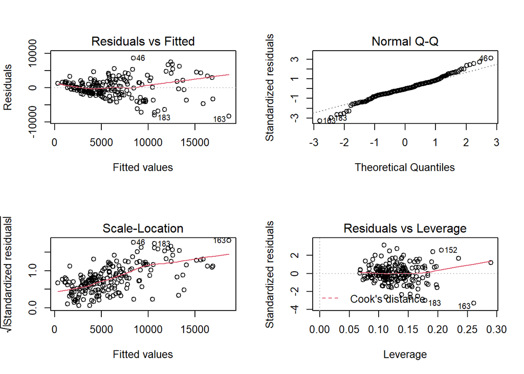

```r
linear_plot <- par(mfrow=c(2,2))
plot(linear_regression_model_full)
```

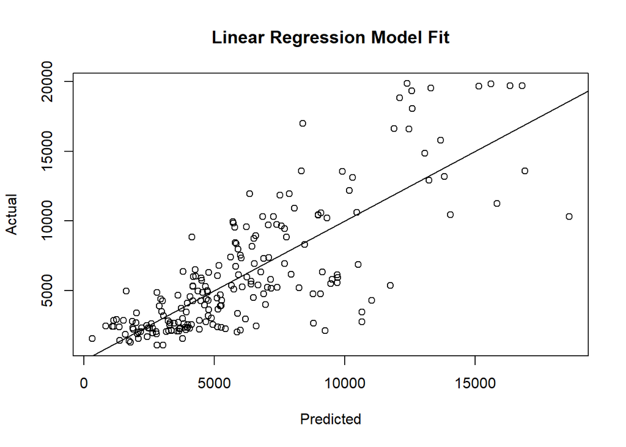

```r
par(linear_plot)

plot(predict(linear_regression_model_full), full_model_train$MonthlyIncome, xlab="Predicted", ylab="Actual", main="Linear Regression Model Fit")
abline(a=0,b=1)
```

### kNN - Optimal Classification and Regression Model Accuracy on Competition set

_This section covers mostly running our optimal classification model (kNN) on the competition applied. Here we applied our optimal model to a new competition “test set” and generated a prediction variable out of it. We then filtered our final results with ID and our predictions as a .csv file to see how we did against an external unlabeled test set in predicting Attrition.__

```r
# reading in classification dataset
class_compete <- read.csv("C:/Users/David/Google Drive/Masters/Summer 2020/DS 6306 - Doing Data Science/Case Study 2/CaseStudy2CompSet No Attrition.csv", header=TRUE)

# excluding variables that was not used in training model
class_compete_test_exclude <- c(2,3,4,8,9,10,12,13,15,16,19,20,22,25,27,32,33,35)
class_compete_test <- class_compete[, -class_compete_test_exclude]

# create new df containing ID and all converted categorical variables into numerical types
class_compete_cat <- c(2,8,10)
for(i in class_compete_cat){
  class_compete_test[, i] <- as.numeric(factor(class_compete_test[,i]))
  # x <- paste(colnames(df_cat_num[i]),"ID", sep="_")
  # colnames(df_cat_num)[i] <- paste(x)
}
str(class_compete_test)
```

```
## 'data.frame':    300 obs. of  17 variables:
##  $ ID                      : int  1171 1172 1173 1174 1175 1176 1177 1178 1179 1180 ...
##  $ Department              : num  2 1 2 2 3 2 3 2 2 2 ...
##  $ DistanceFromHome        : int  28 2 21 2 19 1 29 10 24 20 ...
##  $ Education               : int  3 3 3 3 3 4 4 5 3 3 ...
##  $ EnvironmentSatisfaction : int  2 2 1 3 3 1 1 2 3 1 ...
##  $ JobInvolvement          : int  4 3 3 3 2 2 3 3 2 3 ...
##  $ JobSatisfaction         : int  3 3 3 4 3 1 4 1 1 3 ...
##  $ MaritalStatus           : num  2 2 1 3 1 3 1 2 3 2 ...
##  $ NumCompaniesWorked      : int  1 1 1 2 1 3 2 2 1 3 ...
##  $ OverTime                : num  1 1 1 2 1 1 1 1 1 1 ...
##  $ PercentSalaryHike       : int  17 13 20 13 14 20 15 13 19 12 ...
##  $ RelationshipSatisfaction: int  4 4 3 3 3 3 2 4 2 1 ...
##  $ StockOptionLevel        : int  2 1 1 0 2 0 2 3 0 0 ...
##  $ TotalWorkingYears       : int  10 5 1 30 10 23 16 10 10 12 ...
##  $ TrainingTimesLastYear   : int  3 2 0 2 3 1 3 3 2 2 ...
##  $ WorkLifeBalance         : int  2 3 2 3 3 2 2 3 3 3 ...
##  $ YearsSinceLastPromotion : int  6 1 0 1 0 12 0 7 1 0 ...
```

```r
# adding KNN prediction to competition dataset
class_compete_test$Attrition_pred <- knn(reduced_model_train_knn[,-1], class_compete_test[,-1], reduced_model_train_knn$Attrition_ID, prob=TRUE, k=5)

# cleaning up kNN prediction output then writing out as .csv file
class_compete_test$Attrition_pred_name <- ifelse(as.numeric(class_compete_test$Attrition_pred)==1, "No", "Yes")
class_compete_test <- rename(class_compete_test, Attrition = Attrition_pred_name)
df_classif_output <- class_compete_test[, c(1,19)]
head(df_classif_output, 5)
```

```
##     ID Attrition
## 1 1171        No
## 2 1172       Yes
## 3 1173       Yes
## 4 1174       Yes
## 5 1175       Yes
```

```r
# write.csv(df_classif_output,"C:/Users/David/Google Drive/Masters/Summer 2020/DS 6306 - Doing Data Science/Case Study 2/Case2PredictionsWei Attrition.csv", row.names = FALSE)
```

### Linear Regression - Optimal Classification and Regression Model Accuracy on Competition set

_Similar to the prior section. This section covers mostly running our optimal linear regression model on a competition test set. Here we applied our optimal model to a new competition “test set” and generated a prediction variable out of it. We then filtered our final results with ID and our predictions as a .csv file to see how we did against an external unlabeled test set in predicting Salary (MonthlyIncome).__

```r
# reading in linear regression dataset
linear_compete <- read.csv("C:/Users/David/Google Drive/Masters/Summer 2020/DS 6306 - Doing Data Science/Case Study 2/CaseStudy2CompSet No Salary.csv", header=TRUE)

# excluding variables that was not used in training model
linear_compete_test_exclude <- c(2:5,7:20,22,23,25,27,28,30,31,33,35)
linear_compete_test <- linear_compete[, -linear_compete_test_exclude]
# converting department to num type
linear_compete_test$Department_ID <- as.numeric(factor(linear_compete_test$Department))

# creating prediction using training linear regression model then writing out as a .csv file
linear_compete_test$MonthlyIncome <- predict(linear_regression_model_reduced_auto, linear_compete_test)
# nrow(linear_compete_test)
str(linear_compete_test)
```

```
## 'data.frame':    300 obs. of  10 variables:
##  $ ID                      : int  871 872 873 874 875 876 877 878 879 880 ...
##  $ Department              : chr  "Sales" "Research & Development" "Sales" "Research & Development" ...
##  $ NumCompaniesWorked      : int  1 3 6 1 1 3 0 1 1 3 ...
##  $ PercentSalaryHike       : int  20 18 17 22 11 14 13 20 25 16 ...
##  $ RelationshipSatisfaction: int  3 1 3 2 1 3 1 3 3 2 ...
##  $ TotalWorkingYears       : int  7 5 24 5 7 19 8 2 10 29 ...
##  $ YearsAtCompany          : int  7 3 19 5 7 1 7 2 10 5 ...
##  $ YearsSinceLastPromotion : int  7 0 3 0 0 0 0 2 0 0 ...
##  $ Department_ID           : num  3 2 3 2 2 3 3 2 2 2 ...
##  $ MonthlyIncome           : num  6168 2715 11519 3177 3667 ...
```

```r
df_linear_output <- linear_compete_test[, c(1,10)]
head(df_linear_output, 5)
```

```
##    ID MonthlyIncome
## 1 871      6167.887
## 2 872      2715.196
## 3 873     11519.389
## 4 874      3177.488
## 5 875      3666.683
```

```r
# write.csv(df_linear_output,"C:/Users/David/Google Drive/Masters/Summer 2020/DS 6306 - Doing Data Science/Case Study 2/Case2PredictionsWei Salary.csv", row.names = FALSE)
```